# Towards quantitative DNA Metabarcoding: A method to overcome PCR amplification bias - metabar bias

Sylvain Moinard<sup>1</sup>, Didier Piau<sup>2</sup>, Frédéric Laporte<sup>1</sup>, Delphine Rioux<sup>1</sup>, Pierre Taberlet<sup>1</sup>, Christelle Gonindard-Melodelima<sup>1</sup>, and Eric Coissac<sup>1,✉</sup>

<sup>1</sup> Univ. Grenoble-Alpes, Univ. Savoie Mont Blanc, CNRS, LECA, 38000, Grenoble, France.  
<sup>2</sup> Univ. Grenoble-Alpes, CNRS, Institut Joseph Fourier, 38000, Grenoble, France.

<sup>✉</sup> Correspondence: Eric Coissac <eric.coissac@metabarcoding.org>

This script is used to produce the analyses of the paper. Our data is preprocessed in the data_processing.Rmd file.

Last edit: 10/06/2024

## 1 Setup

## 2 Table 1 and Supplementary Table 1: barcodes

Information about the barcodes used with Sper01 marker.

```r
# Extraction data
extraction <- read.csv("data/processed_data/extraction.csv")

# Barcodes information
barcodes <- read_excel("data/plants_info/new_plant_positive_control.xlsx")[, c(2, 4:6)]
names(barcodes) <- c("species_name", "sequence", "length", "gc_content")

# Polymorphism for species Salvia pratensis
barcodes[barcodes$species_name ==
  "Salvia_pratensis", ]$sequence <-
  "atcctgttttctcaaaacaaaggttcaaaaaacgaaaaaaaaaaag"

barcodes <- barcodes %>% filter(species_name != "Rumex_acetosa")
# This species is not used in this experiment
```

```r
# Information about barcodes and extracted concentrations
barcodes %>% left_join(extraction[, -2])
```

| species_name | sequence | length | gc_content | CDNA_sample |
| --- | --- | --- | --- | --- |
| Taxus_baccata | atccgtattataggaacaataattttattttctagaaaagg | 41 | 24.39024 | 7.94 |
| Taxus_baccata | atccgtattataggaacaataattttattttctagaaaagg | 41 | 24.39024 | 13.30 |
| Salvia_pratensis | atcctgttttctcaaaacaaaggttcaaaaaacgaaaaaaaaaaag | 45 | 26.66667 | 20.80 |
| Salvia_pratensis | atcctgttttctcaaaacaaaggttcaaaaaacgaaaaaaaaaaag | 45 | 26.66667 | 24.40 |
| Populus_tremula | atcctatttttcgaaaacaaacaaaaaaacaaacaaaggttcataaagacagaataagaatacaaaag | 68 | 25.00000 | 33.00 |
| Populus_tremula | atcctatttttcgaaaacaaacaaaaaaacaaacaaaggttcataaagacagaataagaatacaaaag | 68 | 25.00000 | 31.40 |
| Carpinus_betulus | atcctgttttcccaaaacaaataaaacaaatttaagggttcataaagcgagaataaaaaag | 61 | 27.86885 | 13.10 |
| Carpinus_betulus | atcctgttttcccaaaacaaataaaacaaatttaagggttcataaagcgagaataaaaaag | 61 | 27.86885 | 9.14 |
| Fraxinus_excelsior | atcctgttttcccaaaacaaaggttcagaaagaaaaaag | 39 | 33.33333 | 6.56 |
| Fraxinus_excelsior | atcctgttttcccaaaacaaaggttcagaaagaaaaaag | 39 | 33.33333 | 22.40 |

[output cut: 20 more lines]

## 3 Estimation of carrying capacity K from PCR composition

Molar concentration of the 4 dNTP in well: $c_n=0.8 mM = 0.8.10^{-3}mol/l$ (see [AmpliTaq-Gold-360-DNA-Polymerase-QRC-061444](https://assets.fishersci.com/TFS-Assets/LSG/brochures/AmpliTaq-Gold-360-DNA-Polymerase-QRC-061444.pdf))

Quantity of primers in well: $n_p= 20 pmol$/PCR (see [pcr-component-considerations](https://www.thermofisher.com/fr/fr/home/life-science/cloning/cloning-learning-center/invitrogen-school-of-molecular-biology/pcr-education/pcr-reagents-enzymes/pcr-component-considerations.html))

Volume of well: $V = 20 \mu l$

Avogadro Constant $N_A = 6.02214076\times 10^{23} \: mol^{-1}$

Average length of a sequence: $L=51$ dNTP

Thus, $K=min(\frac{c_n\times V}{L}, \: n_p) \times N_A$

This is the maximum number of molecules that can be created in a well. Around 1e13.

```r
c_n <- 4 * 0.2e-3 # concentration of dNTP, mol/l (4*0.2mM)
Vwell <- 20e-6 # volume of a well, l
N_A <- 6.02214076e23 # Avogadro
L <- barcodes$sequence %>%
  nchar() %>%
  mean()
# mean length of a sequence, number of nucleotides

n_p <- 2 * 5e-6 * 2e-6 # quantity of primers, mol : 2 (F+R) * 5uM * 2ul

# Maximum theoretical value of K is Ksup
Ksup <- min(c_n * Vwell / L, n_p) * N_A
Ksup <- n_p * N_A # Primers are limiting

K <- Ksup # K = Ksup assuming PCR reaction is total
```

## 4 Figure 1: PCR models

Fitting exponential and logistic PCR models to qPCR data (SybrGreen) of Capsella bursa-pastoris. Data and script are described in Supplementary File 1.

### 4.1 qPCR data

Converting RFU to number of molecules for illustrative purpose (scaling).

```r
# Open file containing qPCR data
ampli <- read.csv("data/qpcr_sybr/qpcr_Quantification_Amplification_Results_SYBR.csv")[, -1]

# Ampli : data ready for the plot
ampli <- ampli %>% pivot_longer(2:ncol(ampli))
colnames(ampli)[2:3] <- c("Well", "RFU")
ampli <- ampli[ampli$Well == "B7", ] # B7: species Cbp, sample 26

# Convert RFU to molecules
slope <- K / (max(ampli$RFU) - min(ampli$RFU))
intercept <- -slope * min(ampli$RFU)
ampli$molecules <- slope * ampli$RFU + intercept

data_ampli <- as.matrix(ampli[, c("Cycle", "RFU")])
data_ampli[, 1] <- data_ampli[, 1] - 1

ncycles <- nrow(ampli)
```

### 4.2 Fitting PCR models

Parameters are fitted numerically. No biological consideration here. The function (pcrfit) and the data structure used come from R package qpcR.

Non-zero low weights are given for numerical reasons.

```r
mexp <- cm3 # Reuse model object from package qPCR

# Define model

mexp$expr <- "Fluo ~ mexp$fct(Cycles, c(M0, Lam))"
mexp$fct <- function(x, parm) {
  # Simulate amplification with the exponential model
  M0 <- parm[1]
  Lam <- parm[2]
  Fn <- vector(mode = "numeric", length = length(x))
  for (i in 1:length(x)) { # for each cycle
    if (i == 1) {
      Fn[i] <- M0
    } else {
      Fn[i] <- Fn[i - 1] * (1 + Lam)
    }
  }
  return(Fn)
}
mexp$ssFct <- function(x, y) {
  ## start estimates
  ssVal <- c(1, 1)
  names(ssVal) <- mexp$parnames
  return(ssVal)
}
mexp$inv <- function(y, parm) {
  # Inverse of the amplification function
  x <- 1:100
  fn <- function(x, parm) mexp$fct(x, parm) - y
  uniroot(fn, interval = c(1, 100), parm)$root
}
mexp$expr.grad <- expression(mexp$fct(Cycles, c(M0, Lam)))
mexp$parnames <- c("M0", "Lam")
mexp$name <- "mexp"
mexp$type <- "my exponential model"


# Weight cycles

weights_exp <- c(rep(0, 5), rep(1, 9), rep(1000, 6), rep(0, 41))

# Infer best parameters (GLM)
fitexp <- pcrfit(data_ampli, 1, 2, mexp,
  weights = weights_exp
)

# Convert RFU to number of molecules
res_exp <- slope * fitexp$m$predict(newdata = fitexp$DATA) + intercept
```

```r
mlog <- cm3 # Reuse model object from package qPCR

# Define model

mlog$expr <- "Fluo ~ mlog$fct(Cycles, c(M0, Lam))"
mlog$fct <- function(x, parm) {
  # Simulate amplification with the logistic model
  M0 <- parm[1]
  Lam <- parm[2]
  K <- max(ampli$RFU) # specific to this amplification
  Fn <- vector(mode = "numeric", length = length(x))
  for (i in 1:length(x)) {
    if (i == 1) {
      Fn[i] <- M0
    } else {
      if (Fn[i - 1] < K) {
        Fn[i] <- Fn[i - 1] * (1 + Lam * (1 - Fn[i - 1] / K))
      } else {
        Fn[i] <- Fn[i - 1]
      }
    }
  }
  return(Fn)
}
mlog$ssFct <- function(x, y) {
  ## start estimates
  K <- max(ampli$RFU)
  ssVal <- c(1, 1)
  names(ssVal) <- mlog$parnames
  return(ssVal)
}
mlog$inv <- function(y, parm) {
  # Inverse of the amplification function
  x <- 1:100
  fn <- function(x, parm) mlog$fct(x, parm) - y
  uniroot(fn, interval = c(1, 100), parm)$root
}
mlog$expr.grad <- expression(mlog$fct(Cycles, c(M0, Lam)))
mlog$parnames <- c("M0", "Lam")
mlog$name <- "mlog"
mlog$type <- "my logistic model"


# Weight cycles

weights_log <- c(rep(0, 5), rep(1, 9), rep(1000, 10), rep(1, 15), rep(0, 22))

# Infer best parameters (GLM)
fitlog <- pcrfit(data_ampli, 1, 2, mlog,
  weights = weights_log
)

# Convert RFU to number of molecules
res_log <- slope * fitlog$m$predict(newdata = fitlog$DATA) + intercept
```

### 4.3 Figure 1: Fitted PCR models

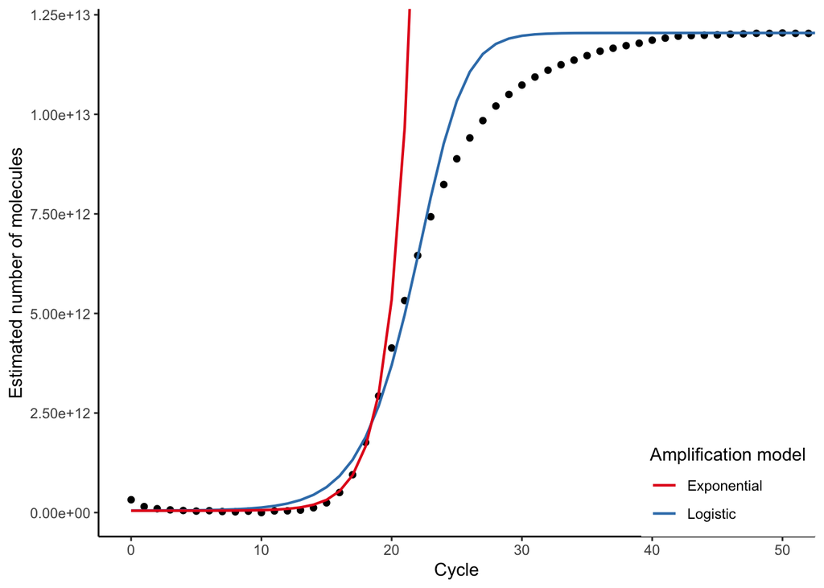

```r
ggplot() +
  # Data:
  geom_point(data = ampli, aes(Cycle - 1, molecules)) +
  # Logistic model:
  geom_line(
    data = NULL, aes(0:60, res_log,
      col = "Logistic"
    ),
    linewidth = 0.75
  ) +
  # Exponential model:
  geom_line(
    data = NULL, aes(0:60, res_exp,
      col = "Exponential"
    ),
    linewidth = 0.75
  ) +
  labs(
    x = "Cycle",
    y = "Estimated number of molecules",
    col = "Amplification model"
  ) +
  theme(
    legend.justification = c(1, 0),
    legend.position = c(1, 0),
    legend.box.margin = margin(rep(10, 4))
  ) +
  scale_colour_brewer(palette = "Set1") +
  coord_cartesian(xlim = c(0, 50), ylim = c(1, K))
```

```r
# ggsave(filename = "Figures/saturation_models.pdf",
#        dpi = 600, units = "mm",
#        width = 150, height = 100, device = "pdf")
```

## 5 Digital droplet PCR (ddPCR) assays

### 5.1 ddPCR data

Dataframe summary_experiment contains all info concerning the concentration assays.

```r
# QuantaSoft output file with additional data (added in data_processing.Rmd)
dataddpcr <- read_csv("data/processed_data/dataddpcr.csv")
# Used columns:
# Sample: Number of the plant sample
# Concentration: Assayed copies/ul in well
# sp: species
# TotalDNA: Total DNA concentration in ddPCR wells, ng/ul

# Open extraction data
# Used columns:
# species name
# Sample: Number of the plant sample
# CDNA_sample: Concentration of total DNA in the sample assayed by Qubit, ng/ul

Vdna_dd <- 5 # Volume of DNA in a well in ul
Vmix_dd <- 20 # Volume of mix in a well in ul

# summary_experiment contains all info concerning the concentration assays
# Molecules_ng is the number of target molecules / ng of total DNA
summary_experiment <- dataddpcr %>%
  group_by(Sample) %>%
  summarise(
    sp = sp[1],
    Molecules_ng = mean(Concentration / TotalDNA)
  ) %>%
  left_join(extraction) %>%
  dplyr::select(Sample, species_name, sp, Molecules_ng, CDNA_sample)
```

## 6 Metabarcoding preparation

DNA concentration in the different communities

### 6.1 Uniform community (M_U)

```r
CDNA_U <- 0.5
# Total DNA concentration in ng/ul for all plants
# in the U community (concentration in sample, not in pcr mix)
C_species_ref <- CDNA_U / 13 # concentration of each species, ng/ul

summary_experiment <- summary_experiment %>%
  mutate(
    Volume_equi = max(Molecules_ng) / Molecules_ng, # Volume to take to be as concentrated as 1 ul of Ptr 6 (most concentrated
    cDNA_U = C_species_ref * Volume_equi,
    # Concentration of total DNA to use in the U commu
    molecules_U = cDNA_U * Molecules_ng, # Molecules/ul in sample
    propU = molecules_U / sum(molecules_U), # species proportion
    RankG = 13 - rank(CDNA_sample / Volume_equi) + 1
  )
```

Number of molecules in the M_U community

```r
VDNA_metab <- 2 # Volume of DNA used in the mix, ul

# Molecules of each species in mix
summary_experiment %>%
  dplyr::select(species_name, molecules_U) %>%
  mutate(molecules_mix = VDNA_metab * molecules_U)
```

| species_name | molecules_U | molecules_mix |
| --- | --- | --- |
| Salvia_pratensis | 9542.154 | 19084.31 |
| Populus_tremula | 9542.154 | 19084.31 |
| Carpinus_betulus | 9542.154 | 19084.31 |
| Fraxinus_excelsior | 9542.154 | 19084.31 |
| Lonicera_xylosteum | 9542.154 | 19084.31 |
| Abies_alba | 9542.154 | 19084.31 |
| Acer_campestre | 9542.154 | 19084.31 |
| Briza_media | 9542.154 | 19084.31 |
| Rosa_canina | 9542.154 | 19084.31 |
| Capsella_bursa-pastoris | 9542.154 | 19084.31 |

[output cut: 3 more lines]

```r
VDNA_metab * sum(summary_experiment$molecules_U) # Total number of molecules
```

```
## [1] 248096
```

### 6.2 “Uniform in Total DNA” Communauty (M_T)

Number of molecules in the M_T community

```r
summary_experiment <- summary_experiment %>%
  mutate(
    molecules_T = C_species_ref * Molecules_ng, # molecules/ul of sample
    propT = molecules_T / sum(molecules_T)
  ) # species proportions

# Molecules of each species in mix
summary_experiment %>%
  dplyr::select(species_name, molecules_T) %>%
  mutate(molecules_mix = VDNA_metab * molecules_T)
```

| species_name | molecules_T | molecules_mix |
| --- | --- | --- |
| Salvia_pratensis | 5880.000 | 11760.000 |
| Populus_tremula | 9542.154 | 19084.308 |
| Carpinus_betulus | 2025.641 | 4051.282 |
| Fraxinus_excelsior | 3347.692 | 6695.385 |
| Lonicera_xylosteum | 2836.154 | 5672.308 |
| Abies_alba | 3448.205 | 6896.410 |
| Acer_campestre | 5180.118 | 10360.237 |
| Briza_media | 4829.744 | 9659.487 |
| Rosa_canina | 8140.000 | 16280.000 |
| Capsella_bursa-pastoris | 1482.051 | 2964.103 |

[output cut: 3 more lines]

```r
VDNA_metab * sum(summary_experiment$molecules_T) # total number of molecules
```

```
## [1] 113443.2
```

### 6.3 Geometric community (M_G)

Number of molecules in the M_G community (2-fold dilution)

```r
summary_experiment <- summary_experiment %>%
  mutate(
    Volume_equi = max(Molecules_ng) / Molecules_ng,
    cDNA_G = CDNA_U / 2^RankG * Volume_equi,
    molecules_G = cDNA_G * Molecules_ng,
    propG = molecules_G / sum(molecules_G)
  )

# Molecules of each species in mix
summary_experiment %>%
  dplyr::select(species_name, molecules_G) %>%
  mutate(molecules_mix = VDNA_metab * molecules_G)
```

| species_name | molecules_G | molecules_mix |
| --- | --- | --- |
| Salvia_pratensis | 3876.50000 | 7753.00000 |
| Populus_tremula | 7753.00000 | 15506.00000 |
| Carpinus_betulus | 60.57031 | 121.14063 |
| Fraxinus_excelsior | 969.12500 | 1938.25000 |
| Lonicera_xylosteum | 1938.25000 | 3876.50000 |
| Abies_alba | 30.28516 | 60.57031 |
| Acer_campestre | 484.56250 | 969.12500 |
| Briza_media | 62024.00000 | 124048.00000 |
| Rosa_canina | 31012.00000 | 62024.00000 |
| Capsella_bursa-pastoris | 242.28125 | 484.56250 |

[output cut: 3 more lines]

```r
sum(summary_experiment$molecules_G) * VDNA_metab # Total number of molecules
```

```
## [1] 248065.7
```

Choice of the order of the species in the Figures

```r
order_sp <- summary_experiment %>%
  dplyr::select(species_name, RankG) %>%
  arrange(-RankG) %>%
  pull(species_name)
```

## 7 Figure 3: ddPCR assays

Target DNA concentrations of each sample

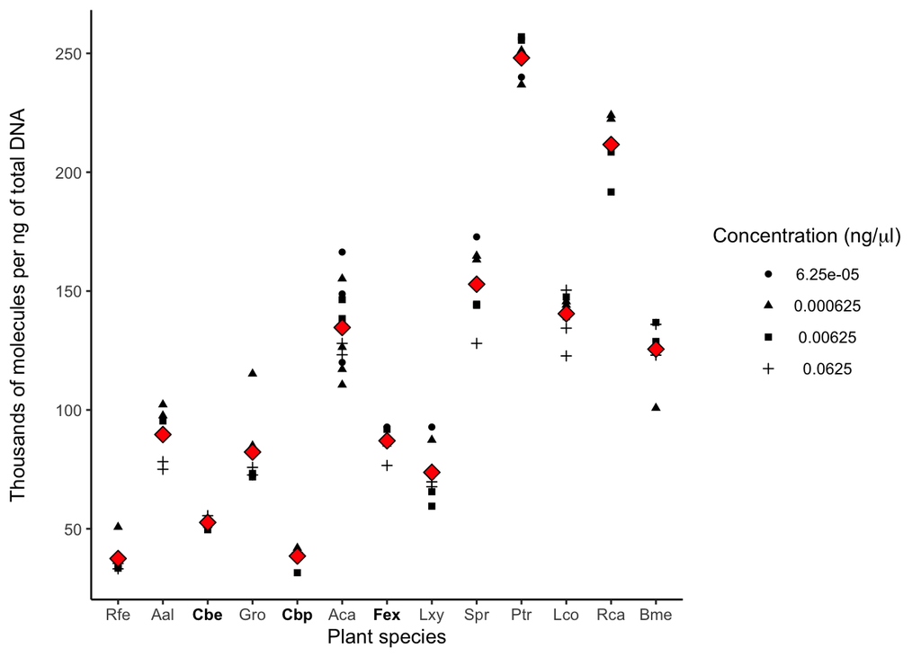

```r
# Open ddpcr data for figure 3
data_dd_fig <- dataddpcr %>%
  left_join(summary_experiment %>% dplyr::select(sp, species_name, RankG))

# Rank of the species
order_short <- summary_experiment %>%
  dplyr::select(sp, RankG) %>%
  arrange(-RankG) %>%
  pull(sp)

highlight <- function(x, pat, color = "black", family = "") {
  ifelse(grepl(pat, x), glue("<b style='font-family:{family}; color:{color}'>{x}</b>"), x)
}

ggplot(data_dd_fig) +
  # Replicates values:
  geom_point(aes(factor(sp, levels = order_short, ordered = T),
    Concentration_copies_ng / 1000,
    shape = as.factor(TotalDNA)
  )) +
  # Median values:
  geom_point(
    data = summary_experiment,
    aes(as.factor(sp), Molecules_ng / 1000),
    fill = "red", shape = 23, size = 3
  ) +
  labs(
    x = "Plant species",
    y = "Thousands of molecules per ng of total DNA\n",
    shape = TeX("Concentration (ng/$\\mu l$)")
  ) +
  scale_x_discrete(labels = function(x) highlight(x, "Cb|Fe")) +
  theme(
    axis.text.x = element_markdown(),
    legend.title.align = 0.5,
    legend.text.align = 0.5
  )
```

```r
# ggsave(filename = "Figures/ddpcr_fig.pdf",
#        dpi = 600, units = "mm",
#        width = 150, height = 100, device = "pdf")
```

Statistics from ddPCR assays:

Species Populus tremula and Rhododendron ferrugineum

Number of copies/ng of total DNA for the two extreme species.

```r
# Populus tremula
data_dd_fig %>%
  filter(sp == "Ptr") %>%
  pull(Concentration_copies_ng) %>%
  summary()
```

```
##    Min. 1st Qu.  Median    Mean 3rd Qu.    Max.
##  236800  240000  251200  248096  255520  256960
```

```r
data_dd_fig %>%
  filter(sp == "Ptr") %>%
  pull(Concentration_copies_ng) %>%
  sd()
```

```
## [1] 9171.504
```

```r
# Rhododendron ferrugineum
data_dd_fig %>%
  filter(sp == "Rfe") %>%
  pull(Concentration_copies_ng) %>%
  summary()
```

```
##    Min. 1st Qu.  Median    Mean 3rd Qu.    Max.
##   33152   33680   34912   37483   37176   50720
```

```r
data_dd_fig %>%
  filter(sp == "Rfe") %>%
  pull(Concentration_copies_ng) %>%
  sd()
```

```
## [1] 6695.412
```

```r
summary_experiment$Molecules_ng %>% summary()
```

```
##    Min. 1st Qu.  Median    Mean 3rd Qu.    Max.
##   37483   73740   89653  113443  140480  248096
```

## 8 Metabarcoding results

Pipeline from raw fastq data: see data_processing.Rmd file (we used the obitools softwares).

Open data, filter bad PCR replicates:

```r
df_Sper01 <- read_csv("data/processed_data/df_Sper01.csv")

# Summarising all information for each sample:
summary_sample <- df_Sper01 %>%
  group_by(Sample) %>%
  summarise(
    total_count_sample = sum(reads),
    NegControl = NegControl[1],
    Spike_level = Spike_level[1],
    Community = Community[1]
  ) %>%
  arrange(total_count_sample)

# Number of reads by sample:
summary(summary_sample$total_count_sample)
```

```
##    Min. 1st Qu.  Median    Mean 3rd Qu.    Max.
##     414   12247   31505   35305   54730  108166
```

```r
# Same without negative controls:
summary(summary_sample %>%
  filter(!NegControl) %>% pull(total_count_sample))
```

```
##    Min. 1st Qu.  Median    Mean 3rd Qu.    Max.
##    1068   13952   33712   37023   55612  108166
```

```r
# Std of number of reads by sample:
sd(summary_sample %>%
  filter(!NegControl) %>% pull(total_count_sample))
```

```
## [1] 26763.09
```

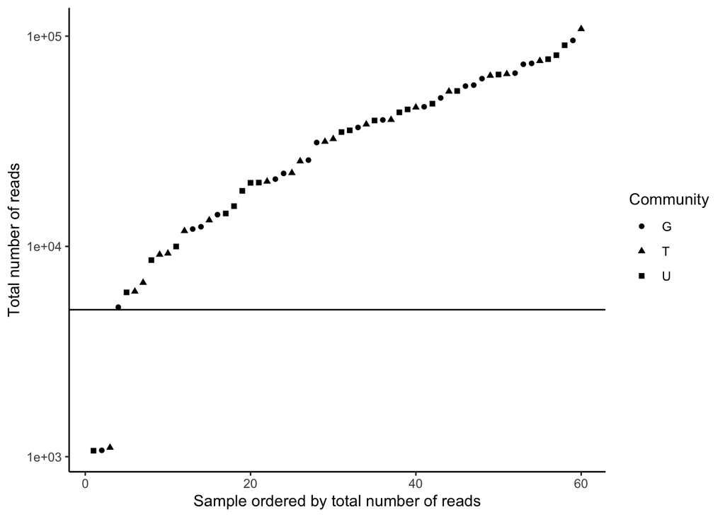

```r
# Replicates with less than 5000 reads are removed
reads_threshold <- 5000

# Plotting all the PCR samples
ggplot(summary_sample %>%
  filter(!NegControl)) +
  geom_point(aes(
    x = 1:nrow(summary_sample %>%
      filter(!NegControl)),
    y = total_count_sample,
    shape = Community
  )) +
  labs(
    x = "Sample ordered by total number of reads",
    y = "Total number of reads"
  ) +
  scale_y_log10() +
  geom_hline(yintercept = reads_threshold)
```

### 8.1 Data preparation

Observed and expected proportions in final composition.

#### 8.1.1 Community M_U

```r
# df_targetU contains clean data of species abundances in each replicates of the M_U community

df_targetU <- df_Sper01 %>%
  filter(Community == "U" &
    species_name %in% barcodes$species_name &
    total_count_sample > reads_threshold &
    !NegControl) %>%
  # observed proportions:
  mutate(prop = obiclean_weight / total_count_sample) %>%
  left_join(summary_experiment %>%
    dplyr::select(species_name, sp, propU)) %>%
  rename(prop_expected = propU)
```

#### 8.1.2 Community M_T

```r
# df_targetT contains clean data of species abundances in each replicates of the M_T community

df_targetT <- df_Sper01 %>%
  filter(Community == "T" &
    species_name %in% barcodes$species_name &
    total_count_sample > reads_threshold &
    !NegControl) %>%
  # observed proportions:
  mutate(prop = obiclean_weight / total_count_sample) %>%
  left_join(summary_experiment %>%
    dplyr::select(species_name, sp, propT)) %>%
  rename(prop_expected = propT)
```

#### 8.1.3 Community M_G

```r
# df_targetG contains clean data of species abundances in each replicates of the M_G community

df_targetG <- df_Sper01 %>%
  filter(Community == "G" &
    species_name %in% barcodes$species_name &
    total_count_sample > reads_threshold &
    !NegControl) %>%
  # observed proportions:
  mutate(prop = obiclean_weight / total_count_sample) %>%
  left_join(summary_experiment %>%
    dplyr::select(species_name, sp, propG)) %>%
  rename(prop_expected = propG)
```

### 8.2 Figure 4: observed and expected proportions

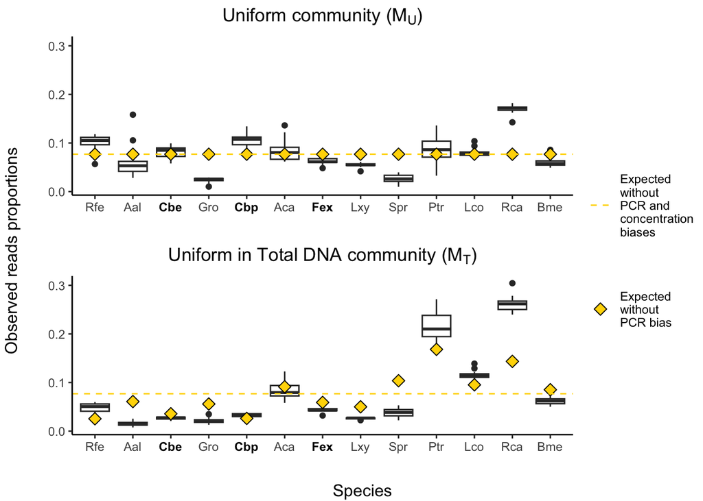

```r
# Choice of colors for the figures:
colp <- c(
  "Expected" = "gold",
  "Expected\nwithout\nPCR bias" = "gold",
  "Expected\nwithout\nPCR and\nconcentration\nbiases" = "gold"
)

# M_U community: obs/expected proportions
gobsU <- ggplot(df_targetU) +
  # Observed proportions:
  geom_boxplot(aes(
    factor(sp, levels = order_short, ordered = T),
    prop
  )) +
  # No PCR bias:
  geom_point(
    data = summary_experiment,
    aes(sp, 1 / nrow(summary_experiment),
      fill = "Expected\nwithout\nPCR bias"
    ),
    shape = 23,
    size = 3
  ) +
  # No bias:
  geom_hline(
    aes(
      yintercept = 1 / nrow(summary_experiment),
      col = "Expected\nwithout\nPCR and\nconcentration\nbiases"
    ),
    linetype = "dashed"
  ) +
  ggtitle(TeX("Uniform community (${{M}_U}$)")) +
  labs(y = "", x = "", fill = "", col = "") +
  ylim(min(df_targetT$prop), max(df_targetT$prop)) +
  theme(
    plot.title = element_text(hjust = 0.5),
    axis.text.x = element_markdown(),
    legend.title.align = 0.5
  ) +
  scale_color_manual(values = colp) +
  scale_fill_manual(values = colp) +
  scale_x_discrete(labels = function(x) highlight(x, "Cb|Fe"))

# M_T community: obs/expected proportions
gobsT <- ggplot(df_targetT) +
  # Observed proportions:
  geom_boxplot(aes(
    factor(sp, levels = order_short, ordered = T),
    prop
  )) +
  # No PCR bias:
  geom_point(
    data = summary_experiment,
    aes(sp, propT, fill = "Expected\nwithout\nPCR bias"),
    shape = 23,
    size = 3
  ) +
  # No bias:
  geom_hline(
    aes(
      yintercept = 1 / nrow(summary_experiment),
      col = "Expected\nwithout\nPCR and\nconcentration\nbiases"
    ),
    linetype = "dashed"
  ) +
  ggtitle(TeX("Uniform in Total DNA community (${{M}_T}$)")) +
  labs(y = "", x = "", fill = "", col = "") +
  theme(
    plot.title = element_text(hjust = 0.5),
    axis.text.x = element_markdown(),
    legend.title.align = 0.5
  ) +
  scale_color_manual(values = colp) +
  scale_fill_manual(values = colp) +
  scale_x_discrete(labels = function(x) highlight(x, "Cb|Fe"))

# Merge both figures
fig <- ggpubr::ggarrange(gobsU, gobsT,
  ncol = 1,
  common.legend = T,
  legend = "right"
)
annotate_figure(fig,
  bottom = text_grob("Species"),
  left = text_grob("Observed reads proportions",
    rot = 90
  )
)
```

```r
# ggsave("Figures/metabar_results.pdf", units = "mm",
#        width = 150, height = 200, dpi = 600, device = "pdf")
```

Statistics about the proportions

```r
df_targetU %>%
  group_by(sp) %>%
  summarise(std = sd(prop), mean = mean(prop)) %>%
  arrange(mean)
```

| sp | std | mean |
| --- | --- | --- |
| Gro | 0.004616929 | 0.02412055 |
| Spr | 0.008487672 | 0.02669224 |
| Lxy | 0.004172129 | 0.05496535 |
| Aal | 0.030124930 | 0.05785689 |
| Bme | 0.009636885 | 0.06075681 |
| Fex | 0.006292988 | 0.06257707 |
| Lco | 0.007698697 | 0.07956988 |
| Cbe | 0.012217148 | 0.08092258 |
| Aca | 0.020729673 | 0.08265734 |
| Ptr | 0.026755339 | 0.08618161 |

[output cut: 3 more lines]

```r
df_targetT %>%
  group_by(sp) %>%
  summarise(std = sd(prop), mean = mean(prop)) %>%
  arrange(mean)
```

| sp | std | mean |
| --- | --- | --- |
| Aal | 0.004705144 | 0.01523829 |
| Gro | 0.005450061 | 0.02111688 |
| Lxy | 0.001741981 | 0.02641436 |
| Cbe | 0.003159537 | 0.02699551 |
| Cbp | 0.003398444 | 0.03255613 |
| Spr | 0.009204829 | 0.03799792 |
| Fex | 0.004409853 | 0.04370252 |
| Rfe | 0.008265616 | 0.04859096 |
| Bme | 0.008930496 | 0.06258690 |
| Aca | 0.016270817 | 0.08380495 |

[output cut: 3 more lines]

```r
df_targetG %>%
  group_by(sp) %>%
  summarise(std = sd(prop), mean = mean(prop)) %>%
  arrange(mean)
```

| sp | std | mean |
| --- | --- | --- |
| Aal | 2.993489e-05 | 5.094424e-05 |
| Rfe | 1.233948e-04 | 1.773308e-04 |
| Gro | 1.405003e-04 | 2.282015e-04 |
| Cbe | 1.313889e-04 | 3.123245e-04 |
| Aca | 4.727137e-04 | 1.655130e-03 |
| Cbp | 4.847829e-04 | 1.886437e-03 |
| Spr | 2.057530e-03 | 6.250511e-03 |
| Fex | 1.501553e-03 | 6.764371e-03 |
| Lxy | 1.807765e-03 | 9.620621e-03 |
| Ptr | 2.283224e-02 | 5.510616e-02 |

[output cut: 3 more lines]

## 9 Ratio correction from a reference mock community (M_U)

This approach considers that the factor bias is independent to the whole community composition.

Correction factor computed from community M_U is:

$$\text{Correction factor: }a_s =
\frac{\text{prop}_{obs}(s)}{\text{prop}_{init}(s)} (\times \:
\text{constant value})$$
Then:

$$\text{Proportions inferred by ratio
method:} \:\: p_s = \frac{\text{prop}_{obs}(s)}{a_s}$$

```r
# CorrecU computes the correction factor
correcU <- df_targetU %>%
  group_by(species_name) %>%
  summarise(correc = median(prop) / prop_expected[1], sp = sp[1])

# Verifying on the M_U community that correction works
df_targetU <- df_targetU %>%
  left_join(correcU) %>%
  mutate(prop_infer_ratio = prop / correc) %>%
  group_by(Sample) %>%
  mutate(prop_infer_ratio = prop_infer_ratio / sum(prop_infer_ratio,
    na.rm = T
  )) %>%
  mutate(species_name = factor(species_name,
    levels = order_sp,
    ordered = T
  ))

# Applying correction to M_T
df_targetT <- df_targetT %>%
  left_join(correcU) %>%
  mutate(prop_infer_ratio = prop / correc) %>%
  group_by(Sample) %>%
  mutate(prop_infer_ratio = prop_infer_ratio / sum(prop_infer_ratio,
    na.rm = T
  )) %>%
  mutate(species_name = factor(species_name,
    levels = order_sp,
    ordered = T
  ))

# Appplying correction to M_G
df_targetG <- df_targetG %>%
  left_join(correcU) %>%
  mutate(prop_infer_ratio = prop / correc) %>%
  group_by(Sample) %>%
  mutate(prop_infer_ratio = prop_infer_ratio / sum(prop_infer_ratio,
    na.rm = T
  )) %>%
  mutate(species_name = factor(species_name,
    levels = order_sp,
    ordered = T
  ))
```

## 10 Efficiencies inference

### 10.1 Export data to Julia

Export data to Julia to infer efficiencies and proportions with flimo

The files used are metabar_bias_functions.jl and inference_efficiencies_ps.jl.

```r
# Reads / species / replicates in M_U
readsU <- df_targetU %>%
  dplyr::select(Sample, obiclean_weight, species_name) %>%
  pivot_wider(
    names_from = species_name,
    values_from = obiclean_weight
  ) %>%
  ungroup() %>%
  dplyr::select(-Sample)

# Initial quantity of molecules in M_U
qty_initU <- left_join(
  data.frame(species_name = colnames(readsU)),
  summary_experiment %>%
    dplyr::select(species_name, molecules_U)
) %>%
  pull(molecules_U) * 2 # 2ul

# write_csv(readsU, "data/export_to_julia/reads_U.csv")
# write_csv(data.frame(qty_initU), "data/export_to_julia/qty_initU.csv")

# Reads / species / replicates in M_T
readsT <- df_targetT %>%
  dplyr::select(Sample, obiclean_weight, species_name) %>%
  pivot_wider(
    names_from = species_name,
    values_from = obiclean_weight
  ) %>%
  ungroup() %>%
  dplyr::select(-Sample)

# Initial quantity of molecules in M_T
qty_initT <- left_join(
  data.frame(species_name = colnames(readsU)),
  summary_experiment %>%
    dplyr::select(species_name, molecules_T)
) %>%
  pull(molecules_T) * 2 # 2ul

# write_csv(readsT, "data/export_to_julia/reads_T.csv")
# write_csv(data.frame(qty_initT), "data/export_to_julia/qty_initT.csv")

# Reads / species / replicates in M_G
readsG <- df_targetG %>%
  dplyr::select(Sample, obiclean_weight, species_name) %>%
  pivot_wider(
    names_from = species_name,
    values_from = obiclean_weight,
    values_fill = 0
  ) %>%
  ungroup() %>%
  dplyr::select(-Sample)

# Initial quantity of molecules in M_G
qty_initG <- left_join(
  data.frame(species_name = colnames(readsU)),
  summary_experiment %>%
    dplyr::select(species_name, molecules_G)
) %>%
  pull(molecules_G) # 2ul

# write_csv(readsG, "data/export_to_julia/reads_G.csv")
# write_csv(data.frame(qty_initG), "data/export_to_julia/qty_initG.csv")
```

### 10.2 Proportions corrected with PCR efficiencies

Proportions inferred in Julia using PCR efficiencies

Run metabar_bias_functions.jl (functions) and inference_efficiencies_ps.jl (inference of efficiencies from M_U and then proportions in M_T and M_G).

#### 10.2.1 Efficiencies

```r
# Inferred efficiencies
efficiencies_infer <- cbind(
  1, # Lambda_RosaCanina
  read_csv("data/export_to_r/efficiencies_U_K13.csv")
)
colnames(efficiencies_infer) <- colnames(readsU)

apply(efficiencies_infer, 2, sd)
```

```
##              Rosa_canina              Briza_media       Lotus_corniculatus
##             0.000000e+00             1.627928e-04             1.270649e-04
##          Populus_tremula           Acer_campestre Rhododendron_ferrugineum
##             9.555390e-05             2.011534e-04             1.345342e-04
##  Capsella_bursa-pastoris       Fraxinus_excelsior         Carpinus_betulus
##             1.752562e-04             1.186408e-04             1.310118e-04
##       Lonicera_xylosteum               Abies_alba         Salvia_pratensis
##             8.289049e-05             1.376501e-04             2.357510e-04
##     Geranium_robertianum
##             2.489240e-04
```

```r
# Add efficiencies to summary_experiment
summary_experiment <- summary_experiment %>%
  left_join(efficiencies_infer %>%
    as_tibble() %>%
    pivot_longer(1:13,
      names_to = "species_name",
      values_to = "efficiencies"
    ) %>%
    group_by(species_name) %>%
    summarise(efficiencies = mean(efficiencies)))
```

#### 10.2.2 Inferred proportions in M_T and M_G

Loading inferred proportions computed in Julia

```r
# Species proportions inferred for M_T in Julia
inferT <- read.csv("data/export_to_r/prop_inferT_K13.csv")
colnames(inferT) <- colnames(readsT)

# Show mean proportions and std of proportions for each species
inferT %>%
  pivot_longer(everything(),
    names_to = "species_name",
    values_to = "prop_infer_Lambda"
  ) %>%
  group_by(species_name) %>%
  summarise(
    prop = mean(prop_infer_Lambda),
    sd = sd(prop_infer_Lambda) / prop
  )
```

| species_name | prop | sd |
| --- | --- | --- |
| Abies_alba | 0.02126173 | 0.005421906 |
| Acer_campestre | 0.08166140 | 0.003457079 |
| Briza_media | 0.08295601 | 0.003900599 |
| Capsella_bursa-pastoris | 0.02477506 | 0.010059073 |
| Carpinus_betulus | 0.02685441 | 0.003494424 |
| Fraxinus_excelsior | 0.05631261 | 0.002626927 |
| Geranium_robertianum | 0.07092861 | 0.024670227 |
| Lonicera_xylosteum | 0.03872964 | 0.006167048 |
| Lotus_corniculatus | 0.11604859 | 0.003526370 |
| Populus_tremula | 0.20303396 | 0.004933666 |

[output cut: 3 more lines]

```r
# Species proportions inferred for M_G in Julia
inferG <- read.csv("data/export_to_r/prop_inferG_K13.csv")
colnames(inferG) <- colnames(readsG)

# Show mean proportions and std of proportions for each species
inferG %>%
  pivot_longer(everything(),
    names_to = "species_name",
    values_to = "prop_infer_Lambda"
  ) %>%
  group_by(species_name) %>%
  summarise(
    prop = mean(prop_infer_Lambda),
    sd_mean = sd(prop_infer_Lambda) / prop
  )
```

| species_name | prop | sd_mean |
| --- | --- | --- |
| Abies_alba | 4.707733e-05 | 0.051798373 |
| Acer_campestre | 1.744974e-03 | 0.009267637 |
| Briza_media | 5.290031e-01 | 0.006675447 |
| Capsella_bursa-pastoris | 1.541584e-03 | 0.023299596 |
| Carpinus_betulus | 3.356815e-04 | 0.035055057 |
| Fraxinus_excelsior | 9.515875e-03 | 0.005800735 |
| Geranium_robertianum | 8.590859e-04 | 0.050834959 |
| Lonicera_xylosteum | 1.538690e-02 | 0.012554283 |
| Lotus_corniculatus | 1.624891e-01 | 0.001368866 |
| Populus_tremula | 5.578277e-02 | 0.002450166 |

[output cut: 3 more lines]

#### 10.2.3 Merge the results

```r
# Raw and Corrected proportions of the different species in M_U
resU <- df_targetU %>%
  group_by(species_name) %>%
  summarise(
    prop = median(prop),
    prop_expected = prop_expected[1],
    prop_infer_ratio = median(prop_infer_ratio)
  )

# Raw and Corrected proportions of the different species in M_T
resT <- df_targetT %>%
  group_by(species_name) %>%
  summarise(
    prop = median(prop), # Observed
    prop_expected = prop_expected[1], # Expected
    prop_infer_ratio = median(prop_infer_ratio)
  ) %>% # Corrected by ratio
  left_join(inferT %>% # inferred with Lambda_s
    pivot_longer(everything(),
      names_to = "species_name",
      values_to = "prop_infer_Lambda"
    ) %>%
    group_by(species_name) %>%
    summarise(
      prop_infer_Lambda = mean(prop_infer_Lambda)
    )) %>%
  arrange(-dplyr::row_number())

# Raw and Corrected proportions of the different species in M_G
resG <- df_targetG %>%
  group_by(species_name) %>%
  summarise(
    prop = median(prop),
    prop_expected = prop_expected[1],
    prop_infer_ratio = median(prop_infer_ratio)
  ) %>%
  left_join(inferG %>%
    pivot_longer(everything(),
      names_to = "species_name",
      values_to = "prop_infer_Lambda"
    ) %>%
    group_by(species_name) %>%
    summarise(
      prop_infer_Lambda = mean(prop_infer_Lambda)
    )) %>%
  arrange(-dplyr::row_number())
```

## 11 Taqman assay

In this section, efficiencies of 3 species are estimated from a Taqman qPCR assay.

Open data (prepared in data_processing.Rmd)

```r
quantif_taqman <- read.csv(
  "data/processed_data/quantification_taqman.csv"
)
kinetics <- read.csv("data/processed_data/taqman_kinetics.csv")
```

Plot amplification curves and Ct = f(concentration)

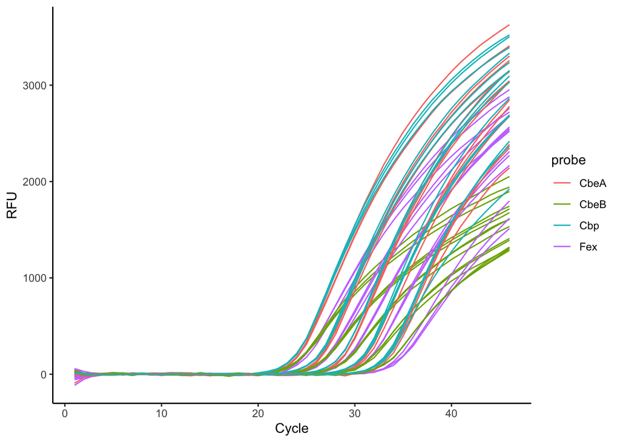

```r
ggplot(kinetics) +
  geom_line(aes(Cycle, RFU, group = Well, col = probe))
```

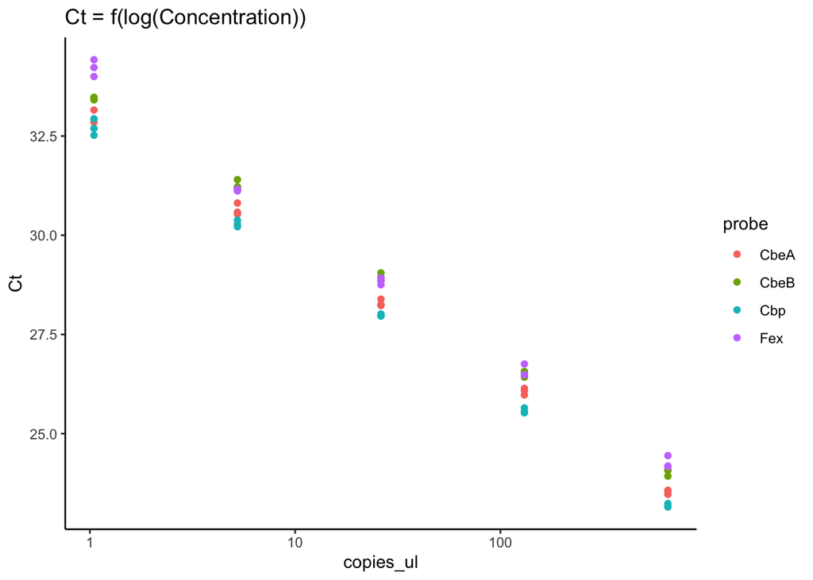

```r
ggplot(quantif_taqman) +
  geom_point(aes(copies_ul, Cq, group = Well, col = probe)) +
  # Cq = quantification cycle = Ct = threshold cycle
  scale_x_log10() +
  labs(y = "Ct") +
  ggtitle("Ct = f(log(Concentration))")
```

### 11.1 First step: linear regression

Using the relation Ct = a log(concentration) + b

```r
Vmix_taq <- 25 # ul volume of a well for Taqman qPCR

quantif_taqman$slope <- NA
quantif_taqman$intercept <- NA

# For each probe, compute the regression
for (s in unique(quantif_taqman$probe)) {
  reg <- lm(
    Cq ~ log10(copies),
    quantif_taqman %>%
      filter(probe == s) %>%
      group_by(Dilu) %>%
      summarise(
        Cq = mean(Cq),
        copies = Vmix_taq * copies_ul[1]
      )
  )

  quantif_taqman[quantif_taqman$probe == s, "slope"] <- reg$coefficients[2]
  quantif_taqman[
    quantif_taqman$probe == s, "intercept"
  ] <- reg$coefficients[1]
}

# Estimate constants of the model

# Estimated efficiency
quantif_taqman$rate <- 10^(-1 / quantif_taqman$slope) - 1

# Estimated number of molecules at C_t
quantif_taqman$Mct <- 10^(-quantif_taqman$intercept / quantif_taqman$slope)

# Show results
quantif_taqman %>%
  group_by(probe) %>%
  summarise(
    rate = rate[1],
    Mct = Mct[1] / 1e11
  )
```

| probe | rate | Mct |
| --- | --- | --- |
| CbeA | 0.9852999 | 1.755191 |
| CbeB | 0.9785392 | 2.306561 |
| Cbp | 0.9677068 | 1.076227 |
| Fex | 0.9303375 | 1.263081 |

```r
# Compute common Mct for the 3 species
Mct_glob <- quantif_taqman %>%
  group_by(sp) %>%
  summarise(Mct = mean(Mct)) %>%
  pull(Mct) %>%
  mean()
```

### 11.2 Computing PCR efficiencies

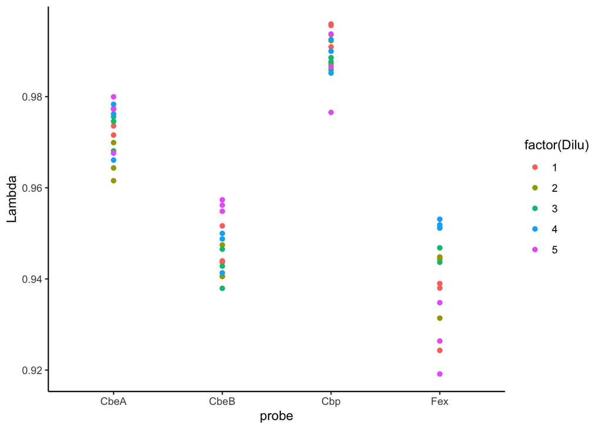

```r
# Computing Lambda from previous estimates
efficiencies <- quantif_taqman %>%
  mutate(Lambda = (Mct_glob / (Vmix_taq * copies_ul))^(1 / Cq) - 1)

# Show results for each species
ggplot(efficiencies) +
  geom_point(aes(probe, Lambda, col = factor(Dilu)))
```

```r
# Averaging by probes
efficiencies %>%
  group_by(probe) %>%
  summarise(Lambda = mean(Lambda))
```

| probe | Lambda |
| --- | --- |
| CbeA | 0.9721340 |
| CbeB | 0.9469116 |
| Cbp | 0.9894763 |
| Fex | 0.9400095 |

```r
# Averaging by species
efficiencies %>%
  group_by(sp) %>%
  summarise(Lambda = mean(Lambda))
```

| sp | Lambda |
| --- | --- |
| Cbe | 0.9595228 |
| Cbp | 0.9894763 |
| Fex | 0.9400095 |

```r
# Lambdas = efficiencies
efficiencies_taq <- efficiencies %>%
  group_by(sp) %>%
  summarise(
    efficiency = mean(Lambda),
    sdeff = sd(Lambda)
  )

quantif_taqman <- quantif_taqman %>% left_join(efficiencies_taq)
```

### 11.3 Observed amplification bias for these 3 species

Comparing the 3 species from the M_U community (amplified within the 13 species pool)

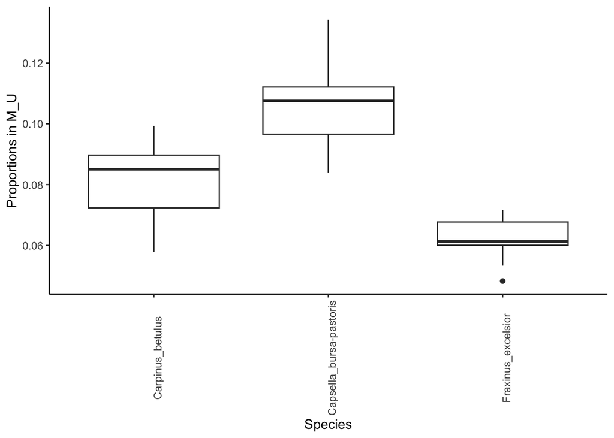

```r
ggplot(df_targetU %>%
  filter(species_name %in% c(
    "Capsella_bursa-pastoris",
    "Carpinus_betulus",
    "Fraxinus_excelsior"
  ))) +
  geom_boxplot(aes(species_name, prop)) +
  labs(x = "Species", y = "Proportions in M_U") +
  theme(axis.text.x = element_text(angle = 90))
```

```r
# Renormalized ps for the 3 species from M_U
df_targetU %>%
  filter(species_name %in% c(
    "Capsella_bursa-pastoris",
    "Carpinus_betulus",
    "Fraxinus_excelsior"
  )) %>%
  group_by(species_name) %>%
  summarise(prop = mean(prop)) %>%
  mutate(prop = prop / sum(prop))
```

| species_name | prop |
| --- | --- |
| Carpinus_betulus | 0.3245764 |
| Capsella_bursa-pastoris | 0.4244301 |
| Fraxinus_excelsior | 0.2509935 |

## 12 Table 2: Amplification efficiencies and proportions in M_U

Summarising previous information

```r
# Proportions observed and expected in M_U
resU %>% dplyr::select(species_name, prop_expected, prop)
```

| species_name | prop_expected | prop |
| --- | --- | --- |
| Rhododendron_ferrugineum | 0.07692308 | 0.10520145 |
| Abies_alba | 0.07692308 | 0.05313812 |
| Carpinus_betulus | 0.07692308 | 0.08504976 |
| Geranium_robertianum | 0.07692308 | 0.02564730 |
| Capsella_bursa-pastoris | 0.07692308 | 0.10754596 |
| Acer_campestre | 0.07692308 | 0.08029834 |
| Fraxinus_excelsior | 0.07692308 | 0.06131492 |
| Lonicera_xylosteum | 0.07692308 | 0.05498790 |
| Salvia_pratensis | 0.07692308 | 0.02613485 |
| Populus_tremula | 0.07692308 | 0.08629834 |

[output cut: 3 more lines]

```r
# Efficiencies estimated by Taqman
efficiencies_taq
```

| sp | efficiency | sdeff |
| --- | --- | --- |
| Cbe | 0.9595228 | 0.014062048 |
| Cbp | 0.9894763 | 0.005009519 |
| Fex | 0.9400095 | 0.010821066 |

```r
# Normalized efficiencies from Taqman
Lambda_Fex <- summary_experiment %>%
  filter(sp == "Fex") %>%
  pull(efficiencies)

efficiencies %>%
  group_by(probe) %>%
  summarise(
    efficiency = mean(Lambda),
    sdeff = sd(Lambda)
  ) %>%
  # Divide Lambda_s so that Lambda_Fex inferred by flimo = Lambda_Fex taqman
  mutate(
    efficiency = efficiency / efficiencies_taq$efficiency[3] * Lambda_Fex,
    sdeff = sdeff / efficiencies_taq$efficiency[3] * Lambda_Fex
  )
```

| probe | efficiency | sdeff |
| --- | --- | --- |
| CbeA | 0.9586697 | 0.005532707 |
| CbeB | 0.9337966 | 0.006024785 |
| Cbp | 0.9757717 | 0.004940136 |
| Fex | 0.9269901 | 0.010671191 |

```r
# Efficiencies estimated with flimo
summary_experiment %>%
  arrange(RankG) %>%
  dplyr::select(species_name, efficiencies)
```

| species_name | efficiencies |
| --- | --- |
| Briza_media | 0.9249252 |
| Rosa_canina | 1.0000000 |
| Lotus_corniculatus | 0.9442679 |
| Populus_tremula | 0.9500593 |
| Salvia_pratensis | 0.8670252 |
| Lonicera_xylosteum | 0.9177919 |
| Fraxinus_excelsior | 0.9269901 |
| Acer_campestre | 0.9469624 |
| Capsella_bursa-pastoris | 0.9648707 |
| Geranium_robertianum | 0.8601241 |

[output cut: 3 more lines]

## 13 Table 3: proportions in M_T and M_G

Inferred proportions in M_T and M_G

### 13.1 Proportions

Inferred with the ratio method or the new approach in this paper

```r
resT
```

| species_name | prop | prop_expected | prop_infer_ratio | prop_infer_Lambda |
| --- | --- | --- | --- | --- |
| Briza_media | 0.06204813 | 0.08514822 | 0.08419945 | 0.08295601 |
| Rosa_canina | 0.26184020 | 0.14350793 | 0.12349410 | 0.12360122 |
| Lotus_corniculatus | 0.11422005 | 0.09525606 | 0.11460567 | 0.11604859 |
| Populus_tremula | 0.21008844 | 0.16822785 | 0.19759268 | 0.20303396 |
| Salvia_pratensis | 0.03854333 | 0.10366420 | 0.11815580 | 0.11528364 |
| Lonicera_xylosteum | 0.02685620 | 0.05000130 | 0.03847964 | 0.03872964 |
| Fraxinus_excelsior | 0.04289456 | 0.05901970 | 0.05683463 | 0.05631261 |
| Acer_campestre | 0.07931554 | 0.09132531 | 0.07813573 | 0.08166140 |
| Capsella_bursa-pastoris | 0.03220041 | 0.02612851 | 0.02449875 | 0.02477506 |
| Geranium_robertianum | 0.02089952 | 0.05580110 | 0.06528607 | 0.07092861 |

[output cut: 3 more lines]

```r
resG
```

| species_name | prop | prop_expected | prop_infer_ratio | prop_infer_Lambda |
| --- | --- | --- | --- | --- |
| Briza_media | 3.640085e-01 | 0.5000610426 | 5.363203e-01 | 5.290031e-01 |
| Rosa_canina | 4.009659e-01 | 0.2500305213 | 1.998077e-01 | 2.020889e-01 |
| Lotus_corniculatus | 1.476582e-01 | 0.1250152607 | 1.602647e-01 | 1.624891e-01 |
| Populus_tremula | 5.197283e-02 | 0.0625076303 | 5.160223e-02 | 5.578277e-02 |
| Salvia_pratensis | 6.031128e-03 | 0.0312538152 | 1.986045e-02 | 2.106384e-02 |
| Lonicera_xylosteum | 9.382567e-03 | 0.0156269076 | 1.469145e-02 | 1.538690e-02 |
| Fraxinus_excelsior | 6.836069e-03 | 0.0078134538 | 9.551650e-03 | 9.515875e-03 |
| Acer_campestre | 1.602123e-03 | 0.0039067269 | 1.701837e-03 | 1.744974e-03 |
| Capsella_bursa-pastoris | 1.923755e-03 | 0.0019533634 | 1.506029e-03 | 1.541584e-03 |
| Geranium_robertianum | 1.949786e-04 | 0.0009766817 | 6.432200e-04 | 8.590859e-04 |

[output cut: 3 more lines]

### 13.2 Proportions with exponential model

Computation of neff for M_U (number of effective exponential cycles) with the truncated exponential model

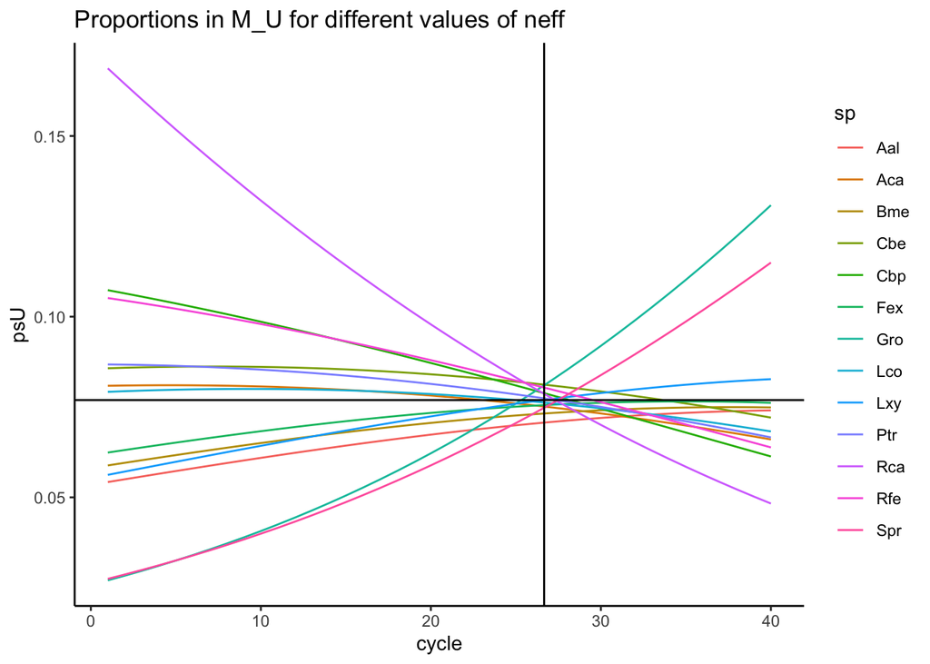

```r
# Combine data in summary_experiment
summary_experiment <- summary_experiment %>%
  left_join(resU %>% dplyr::select(species_name, prop) %>%
    rename(prop_obsU = prop)) %>%
  left_join(resT %>% dplyr::select(species_name, prop) %>%
    rename(prop_obsT = prop)) %>%
  left_join(resG %>% dplyr::select(species_name, prop) %>%
    rename(prop_obsG = prop))

# mg stands for Geometric Mean

# Geometric Mean of Lambda_s + 1
mg_lam_s_p1 <- exp(mean(log(summary_experiment$efficiencies + 1)))

# M_U
# Geometric Mean of relative abundances ps
mg_psU <- exp(mean(log(summary_experiment$prop_obsU)))

# Geometric Mean of initial numbers of molecules m0s
mg_m0sU <- exp(mean(log(VDNA_metab * summary_experiment$molecules_U))) # molecules/ug

# Number of effective exponential cycle for M_U
neffU <- (log(mg_psU) + log(K) - log(mg_m0sU)) / log(mg_lam_s_p1)

# M_T

mg_psT <- exp(mean(log(summary_experiment$prop_obsT)))
mg_m0sT <- exp(mean(log(VDNA_metab * summary_experiment$molecules_T))) # molecules/ug
neffT <- (log(mg_psT) + log(K) - log(mg_m0sT)) / log(mg_lam_s_p1)

# M_G

mg_psG <- exp(mean(log(summary_experiment$prop_obsG)))
mg_m0sG <- exp(mean(log(VDNA_metab * summary_experiment$molecules_G))) # molecules/ug
neffG <- (log(mg_psG) + log(K) - log(mg_m0sG)) / log(mg_lam_s_p1)

# As neff is unknown in practice, what are the inferred proportions for different choosen value of neff ?
Cycles <- 1:40
res_exp <- NULL
for (cyc in Cycles) { # Considering cyc as neff
  m0s <- summary_experiment$prop_obsU /
    (1 + summary_experiment$efficiencies)^cyc
  psU <- m0s / sum(m0s)

  m0s <- summary_experiment$prop_obsT /
    (1 + summary_experiment$efficiencies)^cyc
  psT <- m0s / sum(m0s)

  m0s <- summary_experiment$prop_obsG /
    (1 + summary_experiment$efficiencies)^cyc
  psG <- m0s / sum(m0s)

  res_exp <- rbind(
    res_exp,
    data.frame(
      sp = summary_experiment$sp,
      cycle = cyc,
      psU = psU, psT = psT, psG = psG
    )
  )
}

# Proportions (with exponential model) in M_U for different values of neff
ggplot(res_exp) +
  geom_line(aes(cycle, psU, col = sp)) +
  geom_hline(yintercept = 1 / 13) +
  geom_vline(xintercept = neffU) +
  ggtitle("Proportions in M_U for different values of neff")
```

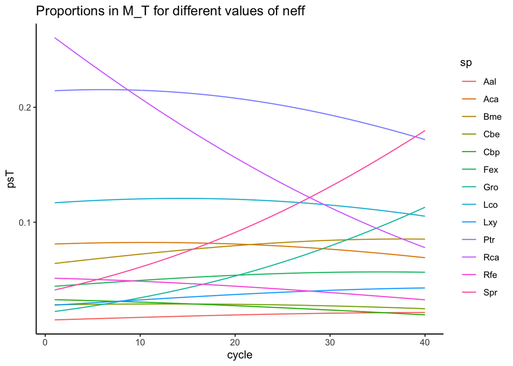

```r
# Proportions (with exponential model) in M_T for different values of neff
ggplot(res_exp) +
  geom_line(aes(cycle, psT, col = sp)) +
  ggtitle("Proportions in M_T for different values of neff")
```

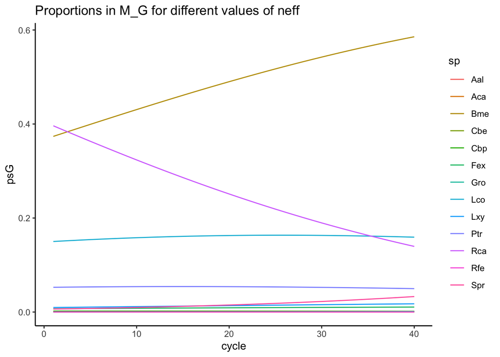

```r
# Proportions(with exponential model)  in M_G for different values of neff
ggplot(res_exp) +
  geom_line(aes(cycle, psG, col = sp)) +
  ggtitle("Proportions in M_G for different values of neff")
```

### 13.3 Estimation error: RMSE values

RMSE (root mean squared error) to compare observed/corrected vs expected proportions Either absolute or relative error

```r
# Absolute Error
AbsErr <- function(p_observed, p_expected) {
  sqrt(sum((p_observed - p_expected)^2) / length(p_observed))
}

# Relative Error
RelErr <- function(p_observed, p_expected) {
  sqrt(sum(((p_observed - p_expected) / p_expected)^2) / length(p_observed))
}

# M_U
summary(resU$prop)
```

```
##    Min. 1st Qu.  Median    Mean 3rd Qu.    Max.
## 0.02565 0.05499 0.07852 0.07646 0.08630 0.17207
```

```r
AbsErr(resU$prop, resU$prop_expected)
```

```
## [1] 0.03702942
```

```r
RelErr(resU$prop, resU$prop_expected)
```

```
## [1] 0.4813825
```

```r
# M_T
summary(resT$prop)
```

```
##    Min. 1st Qu.  Median    Mean 3rd Qu.    Max.
## 0.01454 0.02758 0.04289 0.07551 0.07932 0.26184
```

```r
AbsErr(resT$prop, resT$prop_expected)
```

```
## [1] 0.04465347
```

```r
AbsErr(resT$prop_infer_ratio, resT$prop_expected)
```

```
## [1] 0.01741129
```

```r
AbsErr(resT$prop_infer_Lambda, resT$prop_expected)
```

```
## [1] 0.0185057
```

```r
RelErr(resT$prop, resT$prop_expected)
```

```
## [1] 0.5269626
```

```r
RelErr(resT$prop_infer_ratio, resT$prop_expected)
```

```
## [1] 0.2631424
```

```r
RelErr(resT$prop_infer_Lambda, resT$prop_expected)
```

```
## [1] 0.2793849
```

```r
# RMSE of T if it is considered as a uniform community
AbsErr(resT$prop, resU$prop_expected)
```

```
## [1] 0.07382099
```

```r
RelErr(resT$prop, resU$prop_expected)
```

```
## [1] 0.9596729
```

```r
# M_G
summary(resG$prop)
```

```
##      Min.   1st Qu.    Median      Mean   3rd Qu.      Max.
## 0.0000450 0.0003027 0.0060311 0.0762360 0.0519728 0.4009659
```

```r
AbsErr(resG$prop, resG$prop_expected)
```

```
## [1] 0.05724279
```

```r
AbsErr(resG$prop_infer_ratio, resG$prop_expected)
```

```
## [1] 0.02026261
```

```r
AbsErr(resG$prop_infer_Lambda, resG$prop_expected)
```

```
## [1] 0.01900863
```

```r
RelErr(resG$prop, resG$prop_expected)
```

```
## [1] 0.4930014
```

```r
RelErr(resG$prop_infer_ratio, resG$prop_expected)
```

```
## [1] 0.3358845
```

```r
RelErr(resG$prop_infer_Lambda, resG$prop_expected)
```

```
## [1] 0.3321633
```

Inference at neffU : if the amplification is exponential and is stopped after neffU cycles, the estimated proportions are psU, psT and psG (below). Associated RMSE.

```r
m0s <- summary_experiment$prop_obsU /
  (1 + summary_experiment$efficiencies)^neffU
psU <- m0s / sum(m0s)

m0s <- summary_experiment$prop_obsT /
  (1 + summary_experiment$efficiencies)^neffU
psT <- m0s / sum(m0s)

m0s <- summary_experiment$prop_obsG /
  (1 + summary_experiment$efficiencies)^neffU
psG <- m0s / sum(m0s)

AbsErr(psU, summary_experiment$propU)
```

```
## [1] 0.002994889
```

```r
RelErr(psU, summary_experiment$propU)
```

```
## [1] 0.03893356
```

```r
AbsErr(psT, summary_experiment$propT)
```

```
## [1] 0.0181876
```

```r
RelErr(psT, summary_experiment$propT)
```

```
## [1] 0.2912567
```

```r
AbsErr(psG, summary_experiment$propG)
```

```
## [1] 0.01768139
```

```r
RelErr(psG, summary_experiment$propG)
```

```
## [1] 0.3271845
```

###Associated biodiversity measures: Hill numbers

Computing the Hill numbers to evaluate the influence of correction on ecological conclusions.

```r
# Hill numbers
D <- function(ps, q) {
  ps <- ps / sum(ps)
  ps <- ps[ps > 0]
  ifelse(q == 1, exp(-sum(ps * log(ps))), sum(ps^q)^(1 / (1 - q)))
}

# M_T

D(resT$prop_expected, 1)
```

```
## [1] 11.26119
```

```r
D(resT$prop, 1)
```

```
## [1] 8.868797
```

```r
D(resT$prop_infer_ratio, 1)
```

```
## [1] 10.64034
```

```r
D(resT$prop_infer_Lambda, 1)
```

```
## [1] 10.63299
```

```r
D(resT$prop_expected, 2)
```

```
## [1] 10.02984
```

```r
D(resT$prop, 2)
```

```
## [1] 6.647851
```

```r
D(resT$prop_infer_ratio, 2)
```

```
## [1] 9.125834
```

```r
D(resT$prop_infer_Lambda, 2)
```

```
## [1] 9.108857
```

```r
# M_G

D(resG$prop_expected, 1)
```

```
## [1] 3.995114
```

```r
D(resG$prop, 1)
```

```
## [1] 3.70669
```

```r
D(resG$prop_infer_ratio, 1)
```

```
## [1] 3.733344
```

```r
D(resG$prop_infer_Lambda, 1)
```

```
## [1] 3.810033
```

```r
D(resG$prop_expected, 2)
```

```
## [1] 2.999268
```

```r
D(resG$prop, 2)
```

```
## [1] 3.089144
```

```r
D(resG$prop_infer_ratio, 2)
```

```
## [1] 2.784234
```

```r
D(resG$prop_infer_Lambda, 2)
```

```
## [1] 2.849199
```

## 14 Figure 5: Simulations: impact of efficiency variations

Simulated amplification to quantify the effect of efficiency differences.

### 14.1 Preparing simulations

pcr_sim : Function to simulate PCR with multiple species

```r
pcr_sim <- function(m0 = 1,
                    lambda = rep(1, length(m0)),
                    K = 1e13,
                    cycles = 40,
                    delta = 1) { # for initial overdispersion
  param <- data.frame(
    m0 = m0,
    lambda = lambda
  )
  nspecies <- nrow(param)

  # Number of molecules at each cycle for each species
  kinetics <- matrix(0, nrow = cycles + 1, ncol = nspecies)
  if (delta <= 1) { # Initial variab = Poisson
    for (m in 1:nspecies) {
      kinetics[1, m] <- rpois(1, m0[m])
    }
  } else { # Overdispersed: NegBin
    for (m in 1:nspecies) {
      kinetics[1, m] <- rnbinom(1, m0[m] / delta, 1 / delta)
    }
  }
  for (cyc in 2:(1 + cycles)) {
    charge <- sum(kinetics[cyc - 1, ] - kinetics[1, ]) / K
    for (m in 1:nspecies) {
      lam <- lambda[m]
      mc <- kinetics[cyc - 1, m] # Molecules of s at previous cycle
      lam <- max(0, lam * (1 - charge))
      # Number of created molecules
      nb <- rbinom(1, mc, lam)
      kinetics[cyc, m] <- kinetics[cyc - 1, m] + nb
    }
  }
  return(kinetics)
}

nspecies <- 2
M0 <- rep(2.5e5 / nspecies, nspecies) # Total number of molecules: 2.5e5

# Tested values
lam1 <- 1 # Efficiency of species 1 Rosa Canina
Lam2 <- seq(0.8, 1, by = 0.001) # Different efficiencies of species 2

# Results of the simulated PCR
res <- NULL
for (lam2 in Lam2) {
  p <- pcr_sim(m0 = M0, lambda = c(lam1, lam2), K = K)
  res <- rbind(res, p[41, ])
}

# Proportions of the 2 species
prop2 <- df_targetU %>%
  group_by(sp) %>%
  summarise(propU = median(prop)) %>%
  ungroup() %>%
  mutate(propU = propU / (propU + propU[11])) %>% # 11 = Rca
  left_join(summary_experiment %>%
    dplyr::select(sp, efficiencies)) %>%
  mutate(deff = 1 - efficiencies) %>%
  filter(sp != "Rc")
```

Figure 5:

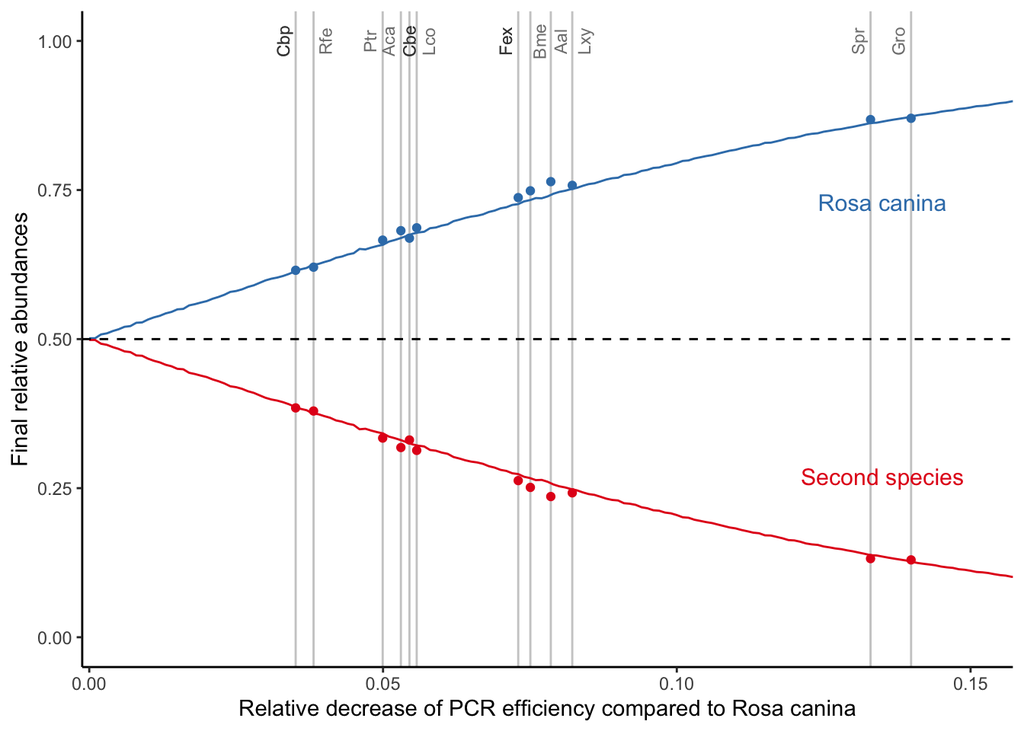

```r
# Labels positions
prop2$labelx <- prop2$deff - 0.0021
prop2[prop2$sp == "Rfe", "labelx"] <- prop2[prop2$sp == "Rfe", "labelx"] +
  0.0042
prop2[prop2$sp == "Lco", "labelx"] <- prop2[prop2$sp == "Lco", "labelx"] +
  0.0042
prop2[prop2$sp == "Lxy", "labelx"] <- prop2[prop2$sp == "Lxy", "labelx"] +
  0.0042
prop2[prop2$sp == "Aal", "labelx"] <- prop2[prop2$sp == "Aal", "labelx"] +
  0.0038
prop2[prop2$sp == "Bme", "labelx"] <- prop2[prop2$sp == "Bme", "labelx"] +
  0.0037
prop2[prop2$sp == "Cbe", "labelx"] <- prop2[prop2$sp == "Cbe", "labelx"] +
  0.0021


ggplot() +
  geom_vline(
    data = prop2 %>% filter(sp != "Rca"),
    aes(xintercept = deff), col = "grey80"
  ) +
  geom_line(aes(1 - Lam2 / lam1, res[, 1] / (rowSums(res)),
    col = "Rosa canina"
  )) +
  geom_line(aes(1 - Lam2 / lam1, res[, 2] / (rowSums(res)), col = "other")) +
  geom_hline(yintercept = 0.5, linetype = "dashed") +
  geom_point(
    data = prop2 %>% filter(sp != "Rca"),
    aes(deff, propU, col = "other")
  ) +
  geom_point(
    data = prop2 %>% filter(sp != "Rca"),
    aes(deff, 1 - propU, col = "Rosa canina")
  ) +
  geom_text(aes(0.135, 0.73,
    label = "Rosa canina",
    col = "Rosa canina"
  ), size = 4) +
  geom_text(aes(0.135, 0.27,
    label = "Second species", col = "other"
  ), size = 4) +
  geom_text(
    data = prop2 %>%
      filter(sp != "Rca") %>% arrange(efficiencies),
    aes(labelx, 1, label = sp),
    col = "grey50", size = 3, angle = 90
  ) +
  geom_text(
    data = prop2 %>%
      filter(sp %in% c("Cbe", "Cbp", "Fex")) %>%
      arrange(efficiencies),
    aes(labelx, 1, label = sp),
    col = "grey25", size = 3, angle = 90
  ) +
  labs(
    x = "Relative decrease of PCR efficiency compared to Rosa canina",
    y = "Final relative abundances", col = "Species"
  ) +
  coord_cartesian(xlim = c(0.006, 0.15), ylim = c(0, 1)) +
  theme(legend.position = "none") +
  scale_colour_brewer(palette = "Set1")
```

```r
# ggsave(filename = "Figures/simu_efficiencies.pdf", units = "mm",
#        height = 100, width = 150, device = "pdf", dpi = 600)
```

## 15 Impact of uncertainty on K

Import all the results from Julia where Lambda_s and proportions were inferred with different values of K ranging from 10^11 to 10^14.

```r
# K = 1.2 10^14
efficiencies_inferK14 <- cbind(
  1,
  read_csv("data/export_to_r/efficiencies_U_K14.csv")
)
colnames(efficiencies_inferK14) <- colnames(readsU)
efficiencies_inferK14 <- efficiencies_inferK14 %>%
  as_tibble() %>%
  pivot_longer(1:13,
    names_to = "species_name",
    values_to = "efficiencies"
  )
efficiencies_inferK14$K <- K * 10

# K = 1.2 10^12
efficiencies_inferK12 <- cbind(
  1,
  read_csv("data/export_to_r/efficiencies_U_K12.csv")
)
colnames(efficiencies_inferK12) <- colnames(readsU)
efficiencies_inferK12 <- efficiencies_inferK12 %>%
  as_tibble() %>%
  pivot_longer(1:13,
    names_to = "species_name",
    values_to = "efficiencies"
  )
efficiencies_inferK12$K <- K / 10

# K = 1.2 10^11
efficiencies_inferK11 <- cbind(
  1,
  read_csv("data/export_to_r/efficiencies_U_K11.csv")
)
colnames(efficiencies_inferK11) <- colnames(readsU)
efficiencies_inferK11 <- efficiencies_inferK11 %>%
  as_tibble() %>%
  pivot_longer(1:13,
    names_to = "species_name",
    values_to = "efficiencies"
  )
efficiencies_inferK11$K <- K / 100

# K = 1.2 10^13
efficiencies_inferK13 <- efficiencies_infer %>%
  as_tibble() %>%
  pivot_longer(1:13,
    names_to = "species_name",
    values_to = "efficiencies"
  )
efficiencies_inferK13$K <- K

# Merged results for supp fig 1
eff_infer_sf1 <- rbind(
  efficiencies_inferK14,
  efficiencies_inferK13,
  efficiencies_inferK12,
  efficiencies_inferK11
) %>%
  left_join(summary_experiment[, 2:3])
```

### 15.1 Supplementary Figure 1

Lambda_s = f(K)

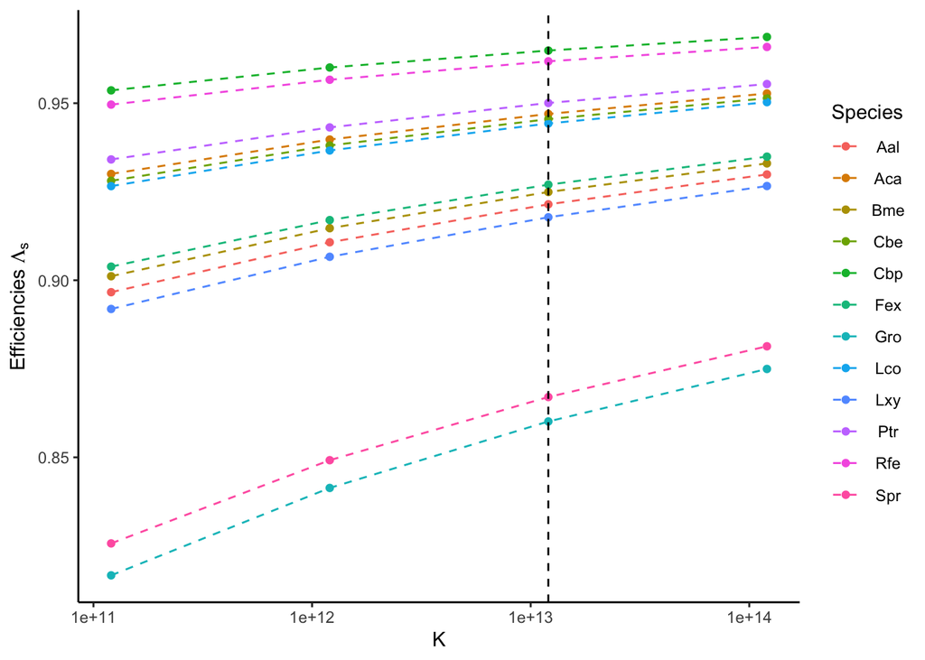

```r
eff_infer_sf1 <- eff_infer_sf1 %>%
  filter(species_name != "Rosa_canina")

ggplot(eff_infer_sf1 %>%
  group_by(sp, K) %>%
  summarise(efficiencies = mean(efficiencies))) +
  geom_point(aes(K, efficiencies, col = sp, group = sp)) +
  geom_line(aes(K, efficiencies, col = sp, group = sp),
    linetype = "dashed"
  ) +
  geom_vline(xintercept = K, linetype = "dashed") +
  scale_x_log10() +
  labs(y = TeX("Efficiencies $\\Lambda_s$"), col = "Species") +
  theme(
    legend.title.align = 0.5,
    legend.text.align = 0.5
  )
```

```r
# ggsave(filename = "Figures/Lambda_fctK.pdf",
#        dpi = 600, units = "mm",
#        width = 150, height = 100, device = "pdf")
```

Normalising by Lambda_min :

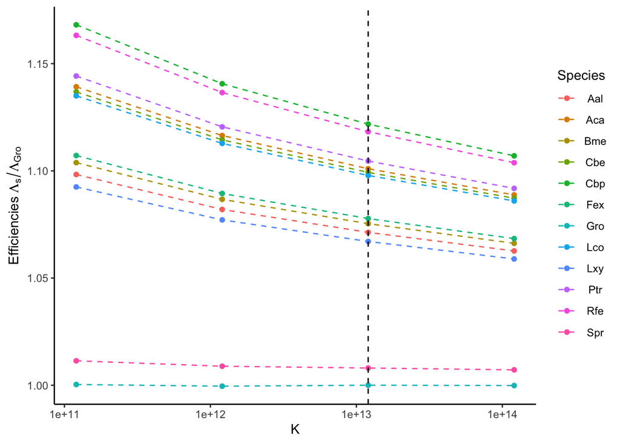

```r
eff_infer_sf1 <- eff_infer_sf1 %>%
  left_join(eff_infer_sf1 %>%
    filter(sp == "Gro") %>%
    dplyr::select(K, efficiencies) %>%
    rename(lambda_min = efficiencies))

ggplot(eff_infer_sf1 %>%
  filter(species_name != "Rosa_canina" & K > 1e11) %>%
  group_by(sp, K) %>%
  summarise(
    efficiencies = mean(efficiencies),
    lambda_min = lambda_min[1]
  )) +
  geom_point(aes(K, efficiencies / lambda_min, col = sp, group = sp)) +
  geom_line(aes(K, efficiencies / lambda_min, col = sp, group = sp),
    linetype = "dashed"
  ) +
  geom_vline(xintercept = K, linetype = "dashed") +
  scale_x_log10() +
  labs(
    y = TeX("Efficiencies $\\Lambda_s / \\Lambda_{Gro}$"),
    col = "Species"
  ) +
  theme(
    legend.title.align = 0.5,
    legend.text.align = 0.5
  )
```

```r
# ggsave(filename = "Figures/Lambda_Lmin_fctK.pdf",
#        dpi = 600, units = "mm",
#        width = 150, height = 100, device = "pdf")
```

## 16 Supplementary Figure 2

Open inference results for MT

```r
# inferT15 <- read.csv("data/export_to_r/prop_inferT_K15.csv") #***
# colnames(inferT15) <- colnames(readsT)
# inferT15 <- inferT15 %>%
#               pivot_longer(everything(),
#                            names_to = "species_name",
#                            values_to = "prop") %>%
#  arrange(-dplyr::row_number())
# inferT15$K <- K*100
# inferT15$type <- "K 10^15"

inferT14 <- read.csv("data/export_to_r/prop_inferT_K14.csv")
colnames(inferT14) <- colnames(readsT)
inferT14 <- inferT14 %>%
  pivot_longer(everything(),
    names_to = "species_name",
    values_to = "prop"
  ) %>%
  arrange(-dplyr::row_number())
inferT14$K <- K * 10
inferT14$type <- "K = 1.2e14"

inferT13 <- read.csv("data/export_to_r/prop_inferT_K13.csv")
colnames(inferT13) <- colnames(readsT)
inferT13 <- inferT13 %>%
  pivot_longer(everything(),
    names_to = "species_name",
    values_to = "prop"
  ) %>%
  arrange(-dplyr::row_number())
inferT13$K <- K
inferT13$type <- "K = 1.2e13"

inferT12 <- read.csv("data/export_to_r/prop_inferT_K12.csv")
colnames(inferT12) <- colnames(readsT)
inferT12 <- inferT12 %>%
  pivot_longer(everything(),
    names_to = "species_name",
    values_to = "prop"
  ) %>%
  arrange(-dplyr::row_number())
inferT12$K <- K / 10
inferT12$type <- "K = 1.2e12"

inferT11 <- read.csv("data/export_to_r/prop_inferT_K11.csv")
colnames(inferT11) <- colnames(readsT)
inferT11 <- inferT11 %>%
  pivot_longer(everything(),
    names_to = "species_name",
    values_to = "prop"
  ) %>%
  arrange(-dplyr::row_number())
inferT11$K <- K / 100
inferT11$type <- "K = 1.2e11"

# inferTK <- rbind(inferT15, inferT14, inferT13, inferT12, inferT11)
inferTK <- rbind(inferT14, inferT13, inferT12, inferT11)
inferTK <- inferTK %>% left_join(summary_experiment[, 2:3])
# add species short names

# Average proportions
inferTK <- inferTK %>%
  group_by(sp, type) %>%
  summarise(
    species_name = species_name[1],
    prop = mean(prop)
  )

# write.csv(inferTK, "data/inferTK.csv")

# Observed proportions
inferTK <- rbind(
  inferTK,
  resT %>% dplyr::select(species_name, prop) %>%
    left_join(summary_experiment %>% dplyr::select(species_name, sp)) %>%
    rename(prop = prop) %>% mutate(type = "Observed")
)

# Theoretical proportions
inferTK <- rbind(
  inferTK,
  resT %>% dplyr::select(species_name, prop_expected) %>%
    left_join(summary_experiment %>% dplyr::select(species_name, sp)) %>%
    rename(prop = prop_expected) %>% mutate(type = "Theoretical")
)

# Proportions corrected by ratio
inferTK <- rbind(
  inferTK,
  resT %>% dplyr::select(species_name, prop_infer_ratio) %>%
    left_join(summary_experiment %>% dplyr::select(species_name, sp)) %>%
    rename(prop = prop_infer_ratio) %>% mutate(type = "Ratio")
)
```

Open inference results for MG

```r
# inferG15 <- read.csv("data/export_to_r/prop_inferG_K15.csv") #***
# colnames(inferG15) <- colnames(readsG)
# inferG15 <- inferG15 %>%
#               pivot_longer(everything(),
#                            names_to = "species_name",
#                            values_to = "prop") %>%
#   arrange(-dplyr::row_number())
# inferG15$K <- K*100
# inferG15$type <- "K 10^15"

inferG14 <- read.csv("data/export_to_r/prop_inferG_K14.csv")
colnames(inferG14) <- colnames(readsG)
inferG14 <- inferG14 %>%
  pivot_longer(everything(),
    names_to = "species_name",
    values_to = "prop"
  ) %>%
  arrange(-dplyr::row_number())
inferG14$K <- K * 10
inferG14$type <- "K = 1.2e14"

inferG13 <- read.csv("data/export_to_r/prop_inferG_K13.csv")
colnames(inferG13) <- colnames(readsG)
inferG13 <- inferG13 %>%
  pivot_longer(everything(),
    names_to = "species_name",
    values_to = "prop"
  ) %>%
  arrange(-dplyr::row_number())
inferG13$K <- K
inferG13$type <- "K = 1.2e13"

inferG12 <- read.csv("data/export_to_r/prop_inferG_K12.csv")
colnames(inferG12) <- colnames(readsG)
inferG12 <- inferG12 %>%
  pivot_longer(everything(),
    names_to = "species_name",
    values_to = "prop"
  ) %>%
  arrange(-dplyr::row_number())
inferG12$K <- K / 10
inferG12$type <- "K = 1.2e12"

inferG11 <- read.csv("data/export_to_r/prop_inferG_K11.csv")
colnames(inferG11) <- colnames(readsG)
inferG11 <- inferG11 %>%
  pivot_longer(everything(),
    names_to = "species_name",
    values_to = "prop"
  ) %>%
  arrange(-dplyr::row_number())
inferG11$K <- K / 100
inferG11$type <- "K = 1.2e11"

# inferGK <- rbind(inferG15, inferG14, inferG13, inferG12, inferG11)
inferGK <- rbind(inferG14, inferG13, inferG12, inferG11)
inferGK <- inferGK %>% left_join(summary_experiment[, 2:3]) # add short names

# average proportions
inferGK <- inferGK %>%
  group_by(sp, type) %>%
  summarise(
    species_name = species_name[1],
    prop = mean(prop)
  )

# write.csv(inferGK, "data/inferGK.csv")

# Observed proportions
inferGK <- rbind(
  inferGK,
  resG %>% dplyr::select(species_name, prop) %>%
    left_join(summary_experiment %>% dplyr::select(species_name, sp)) %>%
    rename(prop = prop) %>% mutate(type = "Observed")
)

# Expected proportions
inferGK <- rbind(
  inferGK,
  resG %>% dplyr::select(species_name, prop_expected) %>%
    left_join(summary_experiment %>% dplyr::select(species_name, sp)) %>%
    rename(prop = prop_expected) %>% mutate(type = "Theoretical")
)

# Proportions corrected by ratio
inferGK <- rbind(
  inferGK,
  resG %>% dplyr::select(species_name, prop_infer_ratio) %>%
    left_join(summary_experiment %>% dplyr::select(species_name, sp)) %>%
    rename(prop = prop_infer_ratio) %>% mutate(type = "Ratio")
)
```

Barplots for the two communities

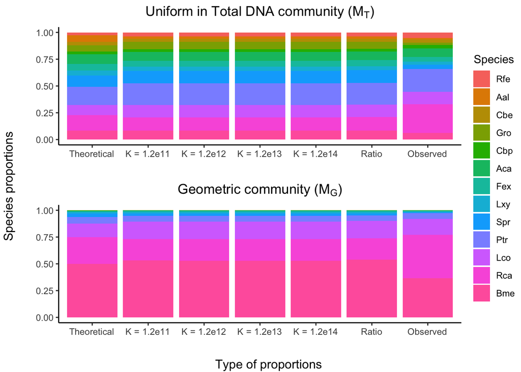

```r
# order_type <- c("Theoretical", "K 10^11", "K 10^12", "K 10^13","K 10^14","K 10^15", "Ratio", "Observed")

order_type <- c("Theoretical", "K = 1.2e11", "K = 1.2e12", "K = 1.2e13", "K = 1.2e14", "Ratio", "Observed")

gTK <- ggplot(inferTK) +
  geom_col(
    aes(
      x = factor(type, levels = order_type, ordered = T),
      y = prop,
      fill = factor(sp, levels = order_short, ordered = T)
    ),
    position = "fill"
  ) +
  scale_fill_manual(values = hue_pal()(13)) +
  ggtitle(TeX("Uniform in Total DNA community (${{M}_T}$)")) +
  labs(x = "", y = "", fill = "Species") +
  theme(
    legend.title = element_text(hjust = 0.5),
    plot.title = element_text(hjust = 0.5),
    axis.text.x = element_markdown()
  )

# ggsave(filename = "Figures/commu_K_MT.pdf",
#        dpi = 600, units = "mm",
#        width = 150, height = 180, device = "pdf")

gGK <- ggplot(inferGK) +
  geom_col(
    aes(
      x = factor(type, levels = order_type, ordered = T),
      y = prop,
      fill = factor(sp, levels = (order_short), ordered = T)
    ),
    position = "fill"
  ) +
  scale_fill_manual(values = hue_pal()(13)) +
  ggtitle(TeX("Geometric community (${{M}_G}$)")) +
  # scale_y_log10()+
  labs(x = "", y = "", fill = "Species") +
  theme(
    legend.title = element_text(hjust = 0.5),
    plot.title = element_text(hjust = 0.5),
    axis.text.x = element_markdown()
  )

# ggsave(filename = "Figures/commu_K_MG.pdf",
#        dpi = 600, units = "mm",
#        width = 150, height = 180, device = "pdf")


# Merge both figures
fig <- ggpubr::ggarrange(gTK, gGK,
  ncol = 1,
  common.legend = T,
  legend = "right"
)
annotate_figure(fig,
  bottom = text_grob("Type of proportions"),
  left = text_grob("Species proportions",
    rot = 90
  )
)
```

```r
# ggsave("Figures/resultsK.pdf", units = "mm",
#        width = 180, height = 200, dpi = 600, device = "pdf")
```

```r
# Proportions vary with K:

inferTK %>%
  filter(type %in% c("K 10^11", "K 10^12", "K 10^14", "K 10^15")) %>% #***
  left_join(
    inferTK %>%
      filter(type == "K 10^13") %>%
      rename(propK13 = prop) %>% dplyr::select(sp, propK13)
  ) %>%
  mutate(variation = (prop - propK13) / propK13) %>%
  group_by(type) %>%
  summarise(
    min_var = min(abs(variation)),
    max_var = max(abs(variation)),
    mean_var = mean(abs(variation))
  )
```

| type | min_var | max_var | mean_var |
| --- | --- | --- | --- |

```r
inferGK %>%
  filter(type %in% c("K 10^11", "K 10^12", "K 10^14", "K 10^15")) %>% #***
  left_join(
    inferGK %>%
      filter(type == "K 10^13") %>%
      rename(propK13 = prop) %>% dplyr::select(sp, propK13)
  ) %>%
  mutate(variation = (prop - propK13) / propK13) %>%
  group_by(type) %>%
  summarise(
    min_var = min(abs(variation)),
    max_var = max(abs(variation)),
    mean_var = mean(abs(variation))
  )
```

| type | min_var | max_var | mean_var |
| --- | --- | --- | --- |

## 17 Supplementary Table 1: C-values

Mass of one genome for the 13 species.

```r
summary_experiment$Cvalue <- c(
  0.46, 0.45, 1.03, 0.84, 0.70, 17.29,
  1.02, 6.35, 1.40, 0.40, 1.76, 0.74, 0.87
)

summary_experiment <- summary_experiment %>%
  mutate(copies_genome = Molecules_ng * 1e9 * Cvalue * 1e-12)

summary_experiment
```

| Sample | species_name | sp | Molecules_ng | CDNA_sample | Volume_equi | cDNA_U | molecules_U | propU | RankG | molecules_T | propT | cDNA_G | molecules_G | propG | efficiencies | prop_obsU | prop_obsT | prop_obsG | Cvalue | copies_genome |
| --- | --- | --- | --- | --- | --- | --- | --- | --- | --- | --- | --- | --- | --- | --- | --- | --- | --- | --- | --- | --- |
| 4 | Salvia_pratensis | Spr | 152880.00 | 24.40 | 1.622815 | 0.06241597 | 9542.154 | 0.07692308 | 5 | 5880.000 | 0.10366420 | 0.0253564887 | 3876.50000 | 0.0312538152 | 0.8670252 | 0.02613485 | 0.03854333 | 6.031128e-03 | 0.46 | 70.32480 |
| 6 | Populus_tremula | Ptr | 248096.00 | 31.40 | 1.000000 | 0.03846154 | 9542.154 | 0.07692308 | 4 | 9542.154 | 0.16822785 | 0.0312500000 | 7753.00000 | 0.0625076303 | 0.9500593 | 0.08629834 | 0.21008844 | 5.197283e-02 | 0.45 | 111.64320 |
| 10 | Carpinus_betulus | Cbe | 52666.67 | 9.14 | 4.710684 | 0.18118014 | 9542.154 | 0.07692308 | 11 | 2025.641 | 0.03571198 | 0.0011500692 | 60.57031 | 0.0004883409 | 0.9455033 | 0.08504976 | 0.02757834 | 3.026634e-04 | 1.03 | 54.24667 |
| 12 | Fraxinus_excelsior | Fex | 87040.00 | 22.40 | 2.850368 | 0.10962952 | 9542.154 | 0.07692308 | 7 | 3347.692 | 0.05901970 | 0.0111342486 | 969.12500 | 0.0078134538 | 0.9269901 | 0.06131492 | 0.04289456 | 6.836069e-03 | 0.84 | 73.11360 |
| 16 | Lonicera_xylosteum | Lxy | 73740.00 | 45.80 | 3.364470 | 0.12940268 | 9542.154 | 0.07692308 | 6 | 2836.154 | 0.05000130 | 0.0262849200 | 1938.25000 | 0.0156269076 | 0.9177919 | 0.05498790 | 0.02685620 | 9.382567e-03 | 0.70 | 51.61800 |
| 18 | Abies_alba | Aal | 89653.33 | 3.58 | 2.767281 | 0.10643390 | 9542.154 | 0.07692308 | 12 | 3448.205 | 0.06079174 | 0.0003378029 | 30.28516 | 0.0002441704 | 0.9214461 | 0.05313812 | 0.01453813 | 4.497414e-05 | 17.29 | 1550.10613 |
| 20 | Acer_campestre | Aca | 134683.08 | 12.20 | 1.842073 | 0.07084894 | 9542.154 | 0.07692308 | 8 | 5180.118 | 0.09132531 | 0.0035977980 | 484.56250 | 0.0039067269 | 0.9469624 | 0.08029834 | 0.07931554 | 1.602123e-03 | 1.02 | 137.37674 |
| 22 | Briza_media | Bme | 125573.33 | 183.00 | 1.975706 | 0.07598870 | 9542.154 | 0.07692308 | 1 | 4829.744 | 0.08514822 | 0.4939265237 | 62024.00000 | 0.5000610426 | 0.9249252 | 0.05775198 | 0.06204813 | 3.640085e-01 | 6.35 | 797.39067 |
| 24 | Rosa_canina | Rca | 211640.00 | 50.80 | 1.172255 | 0.04508672 | 9542.154 | 0.07692308 | 2 | 8140.000 | 0.14350793 | 0.1465318465 | 31012.00000 | 0.2500305213 | 1.0000000 | 0.17207207 | 0.26184020 | 4.009659e-01 | 1.40 | 296.29600 |
| 26 | Capsella_bursa-pastoris | Cbp | 38533.33 | 38.80 | 6.438478 | 0.24763375 | 9542.154 | 0.07692308 | 9 | 1482.051 | 0.02612851 | 0.0062875757 | 242.28125 | 0.0019533634 | 0.9648707 | 0.10754596 | 0.03220041 | 1.923755e-03 | 0.40 | 15.41333 |

[output cut: 3 more lines]

## 18 Supplementary Table 2: initial communities composition

```r
summary_experiment %>% arrange(RankG)
```

| Sample | species_name | sp | Molecules_ng | CDNA_sample | Volume_equi | cDNA_U | molecules_U | propU | RankG | molecules_T | propT | cDNA_G | molecules_G | propG | efficiencies | prop_obsU | prop_obsT | prop_obsG | Cvalue | copies_genome |
| --- | --- | --- | --- | --- | --- | --- | --- | --- | --- | --- | --- | --- | --- | --- | --- | --- | --- | --- | --- | --- |
| 22 | Briza_media | Bme | 125573.33 | 183.00 | 1.975706 | 0.07598870 | 9542.154 | 0.07692308 | 1 | 4829.744 | 0.08514822 | 0.4939265237 | 62024.00000 | 0.5000610426 | 0.9249252 | 0.05775198 | 0.06204813 | 3.640085e-01 | 6.35 | 797.39067 |
| 24 | Rosa_canina | Rca | 211640.00 | 50.80 | 1.172255 | 0.04508672 | 9542.154 | 0.07692308 | 2 | 8140.000 | 0.14350793 | 0.1465318465 | 31012.00000 | 0.2500305213 | 1.0000000 | 0.17207207 | 0.26184020 | 4.009659e-01 | 1.40 | 296.29600 |
| 32 | Lotus_corniculatus | Lco | 140480.00 | 65.20 | 1.766059 | 0.06792535 | 9542.154 | 0.07692308 | 3 | 5403.077 | 0.09525606 | 0.1103787016 | 15506.00000 | 0.1250152607 | 0.9442679 | 0.07852173 | 0.11422005 | 1.476582e-01 | 0.87 | 122.21760 |
| 6 | Populus_tremula | Ptr | 248096.00 | 31.40 | 1.000000 | 0.03846154 | 9542.154 | 0.07692308 | 4 | 9542.154 | 0.16822785 | 0.0312500000 | 7753.00000 | 0.0625076303 | 0.9500593 | 0.08629834 | 0.21008844 | 5.197283e-02 | 0.45 | 111.64320 |
| 4 | Salvia_pratensis | Spr | 152880.00 | 24.40 | 1.622815 | 0.06241597 | 9542.154 | 0.07692308 | 5 | 5880.000 | 0.10366420 | 0.0253564887 | 3876.50000 | 0.0312538152 | 0.8670252 | 0.02613485 | 0.03854333 | 6.031128e-03 | 0.46 | 70.32480 |
| 16 | Lonicera_xylosteum | Lxy | 73740.00 | 45.80 | 3.364470 | 0.12940268 | 9542.154 | 0.07692308 | 6 | 2836.154 | 0.05000130 | 0.0262849200 | 1938.25000 | 0.0156269076 | 0.9177919 | 0.05498790 | 0.02685620 | 9.382567e-03 | 0.70 | 51.61800 |
| 12 | Fraxinus_excelsior | Fex | 87040.00 | 22.40 | 2.850368 | 0.10962952 | 9542.154 | 0.07692308 | 7 | 3347.692 | 0.05901970 | 0.0111342486 | 969.12500 | 0.0078134538 | 0.9269901 | 0.06131492 | 0.04289456 | 6.836069e-03 | 0.84 | 73.11360 |
| 20 | Acer_campestre | Aca | 134683.08 | 12.20 | 1.842073 | 0.07084894 | 9542.154 | 0.07692308 | 8 | 5180.118 | 0.09132531 | 0.0035977980 | 484.56250 | 0.0039067269 | 0.9469624 | 0.08029834 | 0.07931554 | 1.602123e-03 | 1.02 | 137.37674 |
| 26 | Capsella_bursa-pastoris | Cbp | 38533.33 | 38.80 | 6.438478 | 0.24763375 | 9542.154 | 0.07692308 | 9 | 1482.051 | 0.02612851 | 0.0062875757 | 242.28125 | 0.0019533634 | 0.9648707 | 0.10754596 | 0.03220041 | 1.923755e-03 | 0.40 | 15.41333 |
| 28 | Geranium_robertianum | Gro | 82293.33 | 15.00 | 3.014776 | 0.11595294 | 9542.154 | 0.07692308 | 10 | 3165.128 | 0.05580110 | 0.0014720588 | 121.14062 | 0.0009766817 | 0.8601241 | 0.02564730 | 0.02089952 | 1.949786e-04 | 1.76 | 144.83627 |

[output cut: 3 more lines]

## 19 Simulations of mock communities (Supp Fig 3)

100 simulated communities for each of the 3 M0tot values with 13 species

###Varying initial quantity, final abundances

The initial number of molecules varies in the M_U community:

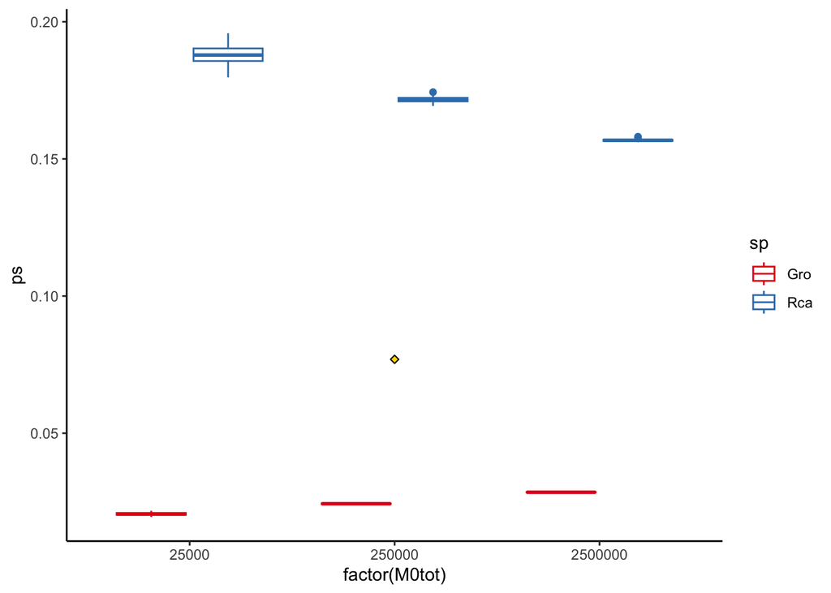

```r
# Different values of total number of molecules at the beginning
M0tot <- 2.5e5 * c(1e-1, 1, 1e1)

# Number of simulated communities
nsim <- 100

# save simulations
compo <- NULL

for (sim in 1:nsim) {
  for (m0tot in M0tot) {
    # Composition of this community
    MU_varM0 <- pcr_sim(
      m0 = rep(
        m0tot / nrow(summary_experiment),
        nrow(summary_experiment)
      ),
      lambda = summary_experiment$efficiencies,
      K = K,
      cycles = ncycles
    )
    compo <- rbind(compo, data.frame(
      sim = sim,
      M0tot = m0tot,
      sp = summary_experiment$sp,
      ps = MU_varM0[nrow(MU_varM0), ] /
        sum(MU_varM0[nrow(MU_varM0), ])
    ))
  }
}

# Plot proportions of the 2 extreme species according to M0tot
ggplot(compo %>% filter(sp %in% c("Rca", "Gro"))) +
  geom_boxplot(aes(factor(M0tot), ps, col = sp)) +
  geom_point(
    data = data.frame(),
    aes(
      factor(M0tot[2]),
      (summary_experiment %>%
        filter(sp %in% c("Rca", "Gro")) %>% pull(propU))
    ),
    shape = 23, fill = "gold"
  ) +
  scale_color_brewer(palette = "Set1")
```

```r
# adjust positions for real proportions...

# Detailed values
compo %>%
  filter(sp %in% c("Rca", "Gro")) %>%
  group_by(M0tot, sp) %>%
  summarise(mps = mean(ps))
```

| M0tot | sp | mps |
| --- | --- | --- |
| 25000 | Gro | 0.02054283 |
| 25000 | Rca | 0.18800665 |
| 250000 | Gro | 0.02429197 |
| 250000 | Rca | 0.17162381 |
| 2500000 | Gro | 0.02847705 |
| 2500000 | Rca | 0.15680760 |

### 19.1 Varying initial quantities, inferred abundances

Data are generated with the logistic model. Corrections are brought with our approach and with the ratio method (assuming exponential model)

#### 19.1.1 Simulate communities

```r
# Reference community is simulated with M0tot = 2.5e5 as in the study
compo_ref <- compo %>%
  filter(M0tot == 2.5e5) %>%
  group_by(sp) %>%
  summarise(med_ps = median(ps)) %>%
  mutate(correc = med_ps / (1 / nrow(summary_experiment)))
# observed ps/expected ps
# with expected ps = 1/13

# Ratio method to correc proportions
compo <- compo %>%
  left_join(summary_experiment[, c("sp", "species_name")]) %>%
  left_join(compo_ref) %>%
  mutate(ps_ratio = ps / correc) # correcting

compo <- compo %>%
  left_join(compo %>% group_by(sim, M0tot) %>%
    summarise(sum_ps_ratio = sum(ps_ratio))) %>% # normalising
  mutate(ps_ratio = ps_ratio / sum_ps_ratio) %>%
  dplyr::select(-sum_ps_ratio)
```

#### 19.1.2 Export to Julia (for inference)

Export simulated communities to Julia for inference.

```r
for (i in 1:length(M0tot)) {
  m0tot <- M0tot[i]
  mat <- compo %>%
    filter(M0tot == m0tot) %>%
    dplyr::select(sim, species_name, ps) %>%
    pivot_wider(names_from = species_name, values_from = ps) %>%
    dplyr::select(colnames(readsU)) %>%
    as.matrix()
  # write.csv(mat, paste0("data/export_to_julia/sim100_m0tot_", i, ".csv"),row.names = F)
}
```

Inference is performed in file inference_simulated_communities.jl

#### 19.1.3 Inference results computed in Julia

Import inference results

```r
res_commu1 <- read.csv("data/export_to_r/res_commu1.csv")
res_commu2 <- read.csv("data/export_to_r/res_commu2.csv")
res_commu3 <- read.csv("data/export_to_r/res_commu3.csv")

colnames(res_commu1) <- colnames(readsU)
colnames(res_commu2) <- colnames(readsU)
colnames(res_commu3) <- colnames(readsU)

res_commu1 <- res_commu1 %>%
  as_tibble() %>%
  mutate(sim = 1:100, M0tot = 2.5e4) %>%
  pivot_longer(1:13, names_to = "species_name", values_to = "ps_log") %>%
  left_join(summary_experiment %>% dplyr::select(sp, species_name))

res_commu2 <- res_commu2 %>%
  as_tibble() %>%
  mutate(sim = 1:100, M0tot = 2.5e5) %>%
  pivot_longer(1:13, names_to = "species_name", values_to = "ps_log") %>%
  left_join(summary_experiment %>% dplyr::select(sp, species_name))

res_commu3 <- res_commu3 %>%
  as_tibble() %>%
  mutate(sim = 1:100, M0tot = 2.5e6) %>%
  pivot_longer(1:13, names_to = "species_name", values_to = "ps_log") %>%
  left_join(summary_experiment %>% dplyr::select(sp, species_name))

res_infer_log <- rbind(res_commu1, res_commu2, res_commu3)
```

#### 19.1.4 Supplementary Figure 3

to compare the two approaches (ratio method and efficiencies inference)

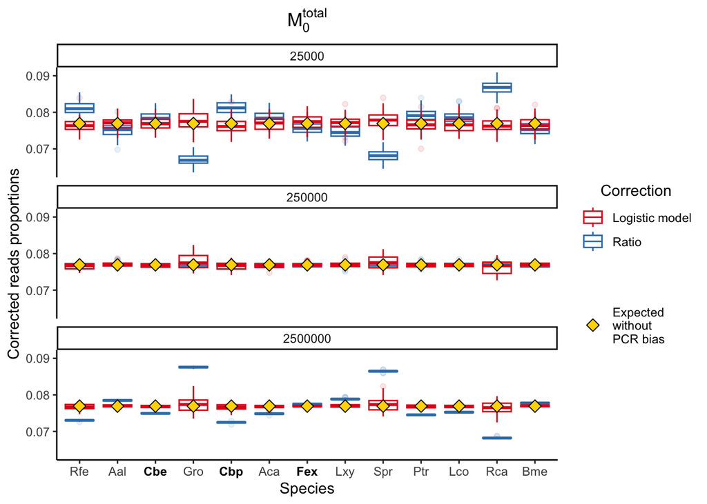

```r
ggplot(compo) +
  geom_boxplot(aes(factor(sp, levels = order_short, ordered = T),
    ps_ratio,
    group = sp, col = "Ratio"
  ), alpha = 0.1) +
  geom_boxplot(data = res_infer_log, aes(sp, ps_log,
    group = sp, col = "Logistic model"
  ), alpha = 0.1) +
  geom_point(
    data = summary_experiment,
    aes(sp, 1 / nrow(summary_experiment),
      fill = "Expected\nwithout\nPCR bias"
    ),
    shape = 23,
    size = 3
  ) +
  facet_wrap(M0tot ~ ., ncol = 1) +
  # scale_color_manual(values = colp)+
  scale_fill_manual(values = colp) +
  labs(
    x = "Species", y = "Corrected reads proportions",
    fill = "", col = "Correction"
  ) +
  scale_color_brewer(palette = "Set1") +
  ggtitle(TeX("$M_0^{{total}}$")) +
  theme(
    legend.title = element_text(hjust = 0.5),
    plot.title = element_text(hjust = 0.5),
    axis.text.x = element_markdown()
  ) +
  scale_x_discrete(labels = function(x) highlight(x, "Cb|Fe"))
```

```r
# ggsave(filename = "Figures/simu_exp_log.pdf",
#        dpi = 600, units = "mm",
#        width = 150, height = 180, device = "pdf")
```

## 20 Number of cycles to perform to reach saturation

How many cycles are needed for a uniform community to reach saturation ?

```r
m0tot <- 2.5e5

pcr_complete <- pcr_sim(
  m0 = rep(
    m0tot / nrow(summary_experiment),
    nrow(summary_experiment)
  ),
  lambda = summary_experiment$efficiencies,
  K = K,
  cycles = ncycles
)

rowSums(pcr_complete) / K
```

```
##  [1] 2.076056e-08 4.012767e-08 7.759176e-08 1.501240e-07 2.905767e-07
##  [6] 5.625869e-07 1.089632e-06 2.110882e-06 4.090889e-06 7.931077e-06
## [11] 1.538049e-05 2.983656e-05 5.789832e-05 1.123858e-04 2.182144e-04
## [16] 4.238054e-04 8.232644e-04 1.599404e-03 3.107013e-03 6.033065e-03
## [21] 1.170148e-02 2.263949e-02 4.358001e-02 8.304880e-02 1.552000e-01
## [26] 2.794935e-01 4.704958e-01 7.069024e-01 9.035886e-01 9.863085e-01
## [31] 9.991323e-01 9.999556e-01 9.999978e-01 9.999999e-01 1.000000e+00
## [36] 1.000000e+00 1.000000e+00 1.000000e+00 1.000000e+00 1.000000e+00
## [41] 1.000000e+00 1.000000e+00 1.000000e+00 1.000000e+00 1.000000e+00
## [46] 1.000000e+00 1.000000e+00 1.000000e+00 1.000000e+00 1.000000e+00
## [51] 1.000000e+00 1.000000e+00 1.000000e+00 1.000000e+00 1.000000e+00
## [56] 1.000000e+00 1.000000e+00 1.000000e+00 1.000000e+00 1.000000e+00
## [61] 1.000000e+00 1.000000e+00
```